# Análisis del paisaje

Autores

Afiliaciones

Víctor Gauto

[GISTAQ (UTN-FRRe)](https://www.instagram.com/gistaq.utn/)

[IIDTHH (UNNE, CONICET)](https://iidthh.conicet.gov.ar/)

[Instituto Gulich (UNC, CONAE)](https://ig.conae.unc.edu.ar/)

Sofía Paná

[Instituto Gulich (UNC, CONAE)](https://ig.conae.unc.edu.ar/)

[IREA (CNR)](http://irea.cnr.it/)

Fecha de publicación

23 de agosto de 2025

# Figuras y tablas

Cantidad de nutrientes para N y P, en miles, y porcentajes, por clase y escenario.

**Ver código**

```r
clases_orden <- c("Grassland", "Forest", "Agriculture", "Urban")
clases_color <- c("#C1D75B", "#58987D", "#75E081", "#8F66B7")

f_gg_nutriente <- function(X) {
  n_p_basin |>
    filter(nut == X) |>
    ggplot(aes(esc, valor, fill = clase)) +
    geom_col(color = NA, show.legend = FALSE) +
    facet_wrap(vars(clase), scales = "free", nrow = 1) +
    scale_y_continuous(
      labels = scales::label_number(
        decimal.mark = ".",
        big.mark = ",",
        scale = 1e-3
      ),
      expand = expansion(add = c(0, 0), mult = c(0, .05))
    ) +
    scale_fill_manual(
      breaks = clases_orden,
      values = clases_color
    ) +
    labs(x = "Escenario") +
    theme_classic(base_size = 7) +
    theme(
      aspect.ratio = 1,
      plot.background = element_blank(),
      axis.ticks = element_line(color = "black"),
      axis.ticks.x = element_blank(),
      axis.title.y = element_blank(),
      axis.text = element_text(color = "black"),
      axis.text.y = element_text(hjust = 1),
      panel.background = element_blank(),
      panel.grid.minor = element_blank(),
      panel.grid.major.y = element_line(color = "black", linewidth = .1),
      panel.grid.major.x = element_blank(),
      strip.background = element_blank(),
      strip.text = element_text(color = "black")
    )
}

fig_nutrientes_1 <- f_gg_nutriente("N")
fig_nutrientes_2 <- f_gg_nutriente("P")

fig_nutrientes_3 <- nutri_tbl |>
  mutate(tipo = fct_reorder(tipo, sum)) |>
  mutate(
    porcentaje = sum / sum(sum),
    .by = c(esc, prod)
  ) |>
  arrange(tipo) |>
  mutate(esc = factor(esc)) |>
  mutate(fraccion = sum / sum(sum), .by = c(esc, prod)) |>
  filter(prod %in% c("n_total_export", "p_surface_export")) |>
  mutate(tipo = factor(tipo, clases_orden)) |>
  ggplot(aes(esc, fraccion, fill = prod)) +
  geom_col(position = position_dodge()) +
  geom_hline(
    data = area_clase_tbl2,
    aes(yintercept = area_prop),
    color = "black",
    linetype = 2,
    linewidth = .4
  ) +
  geom_label(
    data = area_clase_tbl2,
    aes(
      label = paste0(format(area_prop * 100, digits = 2), "%"),
      y = area_prop,
      x = 10
    ),
    vjust = -.1,
    hjust = .5,
    size = 2,
    fill = alpha("white", .5),
    label.size = unit(0, "mm"),
    inherit.aes = FALSE
  ) +
  facet_wrap(vars(tipo), nrow = 1, scales = "free") +
  scale_y_continuous(
    labels = scales::label_percent(),
    expand = expansion(mult = c(0, .1), add = c(0, 0))
  ) +
  scale_fill_manual(
    breaks = c("n_total_export", "p_surface_export"),
    labels = c("N", "P"),
    values = c("#4FB6CA", "#E3C28B")
  ) +
  coord_cartesian(clip = "off") +
  labs(x = "Escenario", fill = NULL) +
  theme_classic(base_size = 7) +
  theme(
    aspect.ratio = 1,
    plot.background = element_blank(),
    axis.ticks = element_line(color = "black"),
    axis.ticks.x = element_blank(),
    axis.title.y = element_blank(),
    axis.text = element_text(color = "black"),
    axis.text.x = element_text(margin = margin(t = 1)),
    axis.text.y = element_text(hjust = 1),
    panel.spacing.x = unit(8, "pt"),
    panel.ontop = FALSE,
    panel.background = element_blank(),
    panel.grid.minor = element_blank(),
    panel.grid.major.y = element_line(color = "black", linewidth = .1),
    panel.grid.major.x = element_blank(),
    strip.background = element_blank(),
    strip.text = element_text(color = "black"),
    legend.position = "top",
    legend.background = element_blank(),
    legend.key.size = unit(.3, "cm"),
    legend.box.spacing = unit(0, "mm"),
    legend.text = element_text(
      margin = margin(r = 10, l = 2),
      size = rel(.8)
    )
  )

fig_nutrientes_comp <- (fig_nutrientes_1 /
  fig_nutrientes_2 /
  fig_nutrientes_3) +
  plot_annotation(
    tag_levels = "A"
  ) &
  theme(
    plot.background = element_blank(),
    plot.tag.position = "topleft",
    plot.tag.location = "margin",
    plot.tag = element_text(
      size = 12,
      margin = margin(b = 0, r = -15),
      face = "bold"
    )
  )

ggsave(
  plot = fig_nutrientes_comp,
  filename = "figuras/nutriente_compuesto_x3.png",
  width = 15,
  height = 15,
  units = "cm"
)
```

[Descargar figura](https://raw.githubusercontent.com/vhgauto/paisaje/refs/heads/main/figuras/nutriente_compuesto_x3.png)

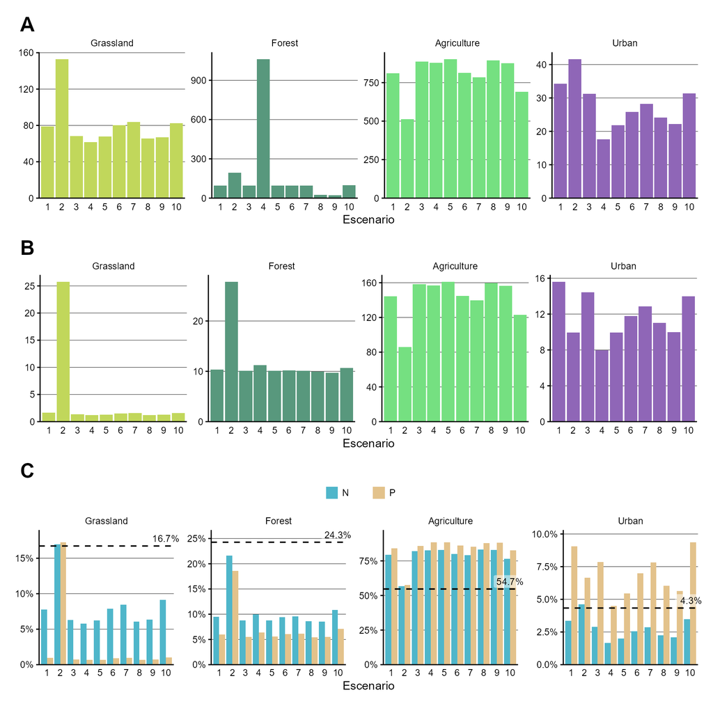

Figura 1: Cantidad de nitrógeno (A) y fósforo (B) por clase y escenario, y proporción de nutrientes respecto de su superficie (C).

Valores de $NDR_{i}$ para N y P, en millones, y porcentajes, por clase y escenario.

**Ver código**

```r
ndri_valor <- readxl::read_xlsx("datos/ndri_nutri.xlsx") |>
  janitor::clean_names() |>
  select(nutriente, esc, forest, grassland, agriculture, urban) |>
  mutate(esc = str_remove(esc, "SCENARIO ")) |>
  mutate(esc = as.numeric(esc)) |>
  pivot_longer(
    cols = -c(esc, nutriente),
    values_to = "ndri",
    names_to = "tipo"
  ) |>
  mutate(tipo = str_to_sentence(tipo)) |>
  mutate(tipo = factor(tipo, clases_orden)) |>
  mutate(esc = factor(esc)) |>
  mutate(
    suma = sum(ndri),
    .by = c(nutriente, esc)
  ) |>
  mutate(
    prop = ndri / suma
  )

f_gg_ndri <- function(X) {
  ndri_valor |>
    filter(nutriente == X) |>
    ggplot(aes(esc, ndri, fill = tipo)) +
    geom_col(show.legend = FALSE) +
    facet_wrap(vars(tipo), nrow = 1, scales = "free") +
    scale_y_continuous(
      labels = scales::label_number(
        scale = 1e-6,
        decimal.mark = ".",
        big.mark = ","
      ),
      expand = expansion(add = c(0, 0), mult = c(0, .05))
    ) +
    scale_fill_manual(
      breaks = clases_orden,
      values = clases_color
    ) +
    labs(x = "Escenario") +
    theme_classic(base_size = 7) +
    theme(
      aspect.ratio = 1,
      plot.background = element_blank(),
      axis.ticks = element_line(color = "black"),
      axis.ticks.x = element_blank(),
      axis.title.y = element_blank(),
      axis.text = element_text(color = "black"),
      axis.text.y = element_text(hjust = 1),
      panel.background = element_blank(),
      panel.grid.minor = element_blank(),
      panel.grid.major.y = element_line(color = "black", linewidth = .1),
      panel.grid.major.x = element_blank(),
      strip.background = element_blank(),
      strip.text = element_text(color = "black")
    )
}

fig_ndri_1 <- f_gg_ndri("N")
fig_ndri_2 <- f_gg_ndri("P")

fig_ndri_3 <- ndri_valor |>
  ggplot(aes(esc, prop, fill = nutriente)) +
  geom_col(position = position_dodge(), show.legend = TRUE) +
  geom_hline(
    data = area_clase_tbl2,
    aes(yintercept = area_prop),
    color = "black",
    linetype = 2,
    linewidth = .4
  ) +
  geom_label(
    data = area_clase_tbl2,
    aes(
      label = paste0(format(area_prop * 100, digits = 2), "%"),
      y = area_prop,
      x = Inf
    ),
    vjust = -.1,
    hjust = 1,
    size = 2,
    fill = alpha("white", .8),
    label.size = unit(0, "mm"),
    label.padding = unit(0, "mm"),
    label.r = unit(0, "mm"),
    inherit.aes = FALSE
  ) +
  facet_wrap(vars(tipo), nrow = 1, scales = "free") +
  scale_y_continuous(
    labels = scales::label_percent(),
    expand = expansion(add = c(0, 0), mult = c(0, .05))
  ) +
  scale_fill_manual(
    breaks = c("N", "P"),
    values = c("#4FB6CA", "#E3C28B")
  ) +
  coord_cartesian(clip = "off") +
  labs(x = "Escenario", fill = NULL) +
  theme_classic(base_size = 7) +
  theme(
    aspect.ratio = 1,
    plot.background = element_blank(),
    axis.ticks = element_line(color = "black"),
    axis.ticks.x = element_blank(),
    axis.title.y = element_blank(),
    axis.text = element_text(color = "black"),
    axis.text.y = element_text(hjust = 1),
    panel.background = element_blank(),
    panel.grid.minor = element_blank(),
    panel.grid.major.y = element_line(color = "black", linewidth = .1),
    panel.grid.major.x = element_blank(),
    panel.spacing.x = unit(12, "pt"),
    strip.background = element_blank(),
    strip.text = element_text(color = "black"),
    legend.position = "top",
    legend.background = element_blank(),
    legend.key.size = unit(.3, "cm"),
    legend.box.spacing = unit(0, "mm"),
    legend.text = element_text(
      margin = margin(r = 10, l = 2),
      size = rel(.8)
    )
  )

fig_ndri_comp <- (fig_ndri_1 / fig_ndri_2 / fig_ndri_3) +
  plot_annotation(
    tag_levels = "A"
  ) &
  theme(
    plot.background = element_blank(),
    plot.tag.position = "topleft",
    plot.tag.location = "margin",
    plot.tag = element_text(
      size = 12,
      margin = margin(b = 0, r = -15),
      face = "bold"
    )
  )

ggsave(
  plot = fig_ndri_comp,
  filename = "figuras/ndri_compuesto_x3.png",
  width = 15,
  height = 15,
  units = "cm"
)
```

[Descargar figura](https://raw.githubusercontent.com/vhgauto/paisaje/refs/heads/main/figuras/ndri_compuesto_x3.png)

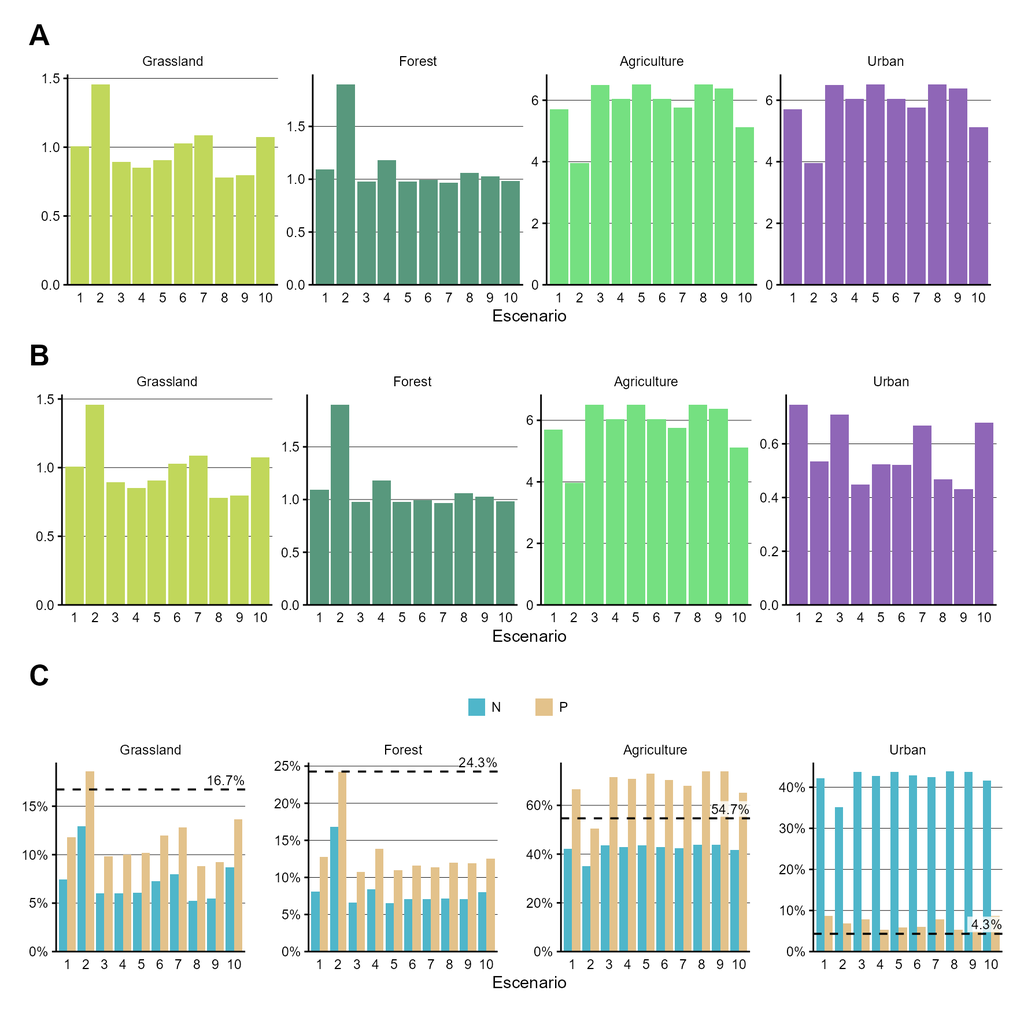

Figura 2: $NDR_{i}$ de nitrógeno (A) y fósforo (B) por clase y escenario, y porcentajes respecto de su superficie (C).

Las figuras a continuación muestran las cantidades de nutrientes por clase y escenario.

**Ver código**

```r
clases_orden <- c("Grassland", "Forest", "Agriculture", "Urban")
clases_color <- c("#C1D75B", "#58987D", "#75E081", "#8F66B7")

n_p_basin <- readxl::read_xlsx("datos/n_p_basin.xlsx") |>
  janitor::clean_names() |>
  mutate(
    nut = if_else(str_detect(x1, "N_total"), "N", "P"),
    esc = case_when(
      nut == "N" ~ str_remove(x1, "N_totalS"),
      nut == "P" ~ str_remove(x1, "P_SUR_S")
    )
  ) |>
  select(nut, esc, forest, grassland, agriculture, urban) |>
  mutate(esc = as.numeric(esc)) |>
  pivot_longer(
    cols = -c(nut, esc),
    values_to = "valor",
    names_to = "clase"
  ) |>
  mutate(clase = str_to_sentence(clase)) |>
  mutate(clase = factor(clase, clases_orden)) |>
  mutate(esc = factor(esc))

f_gg_nutriente <- function(X) {
  g <- n_p_basin |>
    filter(nut == X) |>
    ggplot(aes(esc, valor, fill = clase)) +
    geom_col(color = NA, show.legend = FALSE) +
    facet_wrap(vars(clase), scales = "free", nrow = 1) +
    scale_y_continuous(
      labels = scales::label_number(
        decimal.mark = ".",
        big.mark = ",",
        scale = 1e-3
      ),
      expand = expansion(add = c(0, 0), mult = c(0, .05))
    ) +
    scale_fill_manual(
      breaks = clases_orden,
      values = clases_color
    ) +
    labs(x = "Escenario") +
    theme_classic(base_size = 7) +
    theme(
      aspect.ratio = 1,
      plot.background = element_blank(),
      axis.ticks = element_line(color = "black"),
      axis.ticks.x = element_blank(),
      axis.title.y = element_blank(),
      axis.text = element_text(color = "black"),
      axis.text.y = element_text(hjust = 1),
      panel.background = element_blank(),
      panel.grid.minor = element_blank(),
      panel.grid.major.y = element_line(color = "black", linewidth = .1),
      panel.grid.major.x = element_blank(),
      strip.background = element_blank(),
      strip.text = element_text(color = "black")
    )

  ggsave(
    plot = g,
    filename = paste0("figuras/nutriente_", X, ".png"),
    width = 15,
    height = 4.25,
    units = "cm"
  )
}

f_gg_nutriente("N")
f_gg_nutriente("P")
```

Cantidad de nitrógeno, en miles.

**NotaMostrar imagen**

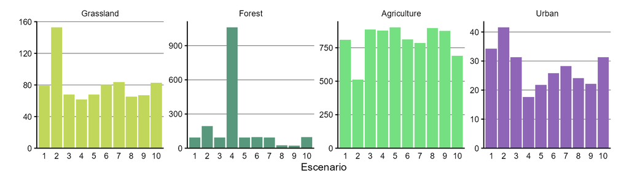

Figura 3: Cantidad de nitrógeno por clase y escenario.

Cantidad de fósforo, en miles.

**NotaMostrar imagen**

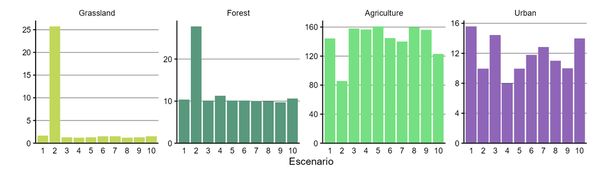

Figura 4: Cantidad de fósforo por clase y escenario.

Se combinaron las figuras 3 y 4 para generar la siguiente, que muestra las cantidades, en miles de nitrógeno (A) y fósforo (B), por clase y escenario.

**Ver código**

```r
f_gg_nutriente <- function(X) {
  n_p_basin |>
    filter(nut == X) |>
    ggplot(aes(esc, valor, fill = clase)) +
    geom_col(color = NA, show.legend = FALSE) +
    facet_wrap(vars(clase), scales = "free", nrow = 1) +
    scale_y_continuous(
      labels = scales::label_number(
        decimal.mark = ".",
        big.mark = ",",
        scale = 1e-3
      ),
      expand = expansion(add = c(0, 0), mult = c(0, .05))
    ) +
    scale_fill_manual(
      breaks = clases_orden,
      values = clases_color
    ) +
    labs(x = "Escenario") +
    theme_classic(base_size = 7) +
    theme(
      aspect.ratio = 1,
      plot.background = element_blank(),
      axis.ticks = element_line(color = "black"),
      axis.ticks.x = element_blank(),
      axis.title.y = element_blank(),
      axis.text = element_text(color = "black"),
      axis.text.y = element_text(hjust = 1),
      panel.background = element_blank(),
      panel.grid.minor = element_blank(),
      panel.grid.major.y = element_line(color = "black", linewidth = .1),
      panel.grid.major.x = element_blank(),
      strip.background = element_blank(),
      strip.text = element_text(color = "black")
    )
}

fig1 <- f_gg_nutriente("N")
fig2 <- f_gg_nutriente("P")

fig3 <- (fig1 / fig2) +
  plot_annotation(
    tag_levels = "A"
  ) &
  theme(
    plot.background = element_blank(),
    plot.tag.position = "topleft",
    plot.tag.location = "margin",
    plot.tag = element_text(
      size = 12,
      margin = margin(b = 0, r = -15),
      face = "bold"
    )
  )

ggsave(
  plot = fig3,
  filename = "figuras/nutriente_compuesto.png",
  width = 15,
  height = 10,
  units = "cm"
)
```

**Ejes verticales individuales**

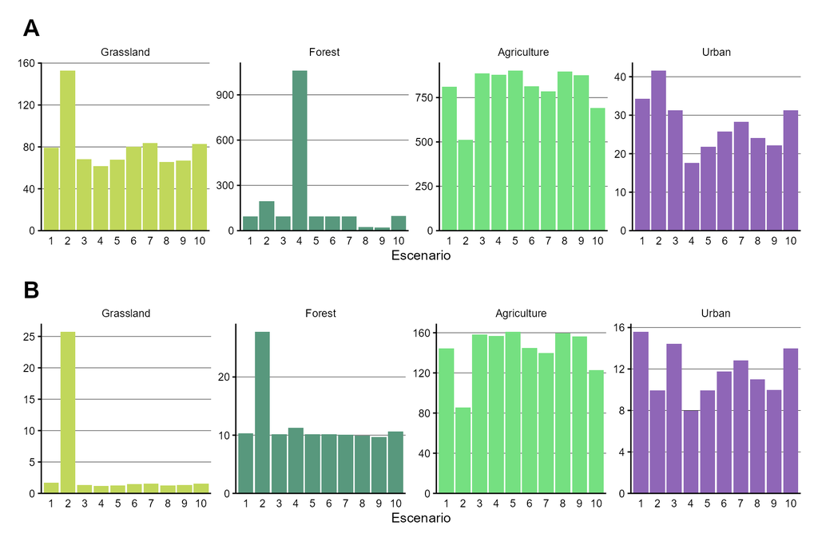

Figura 5: Cantidades, en miles, de nitrógeno (**A**) y fósforo (**B**) por clase y escenario

**Eje vertical compartido**

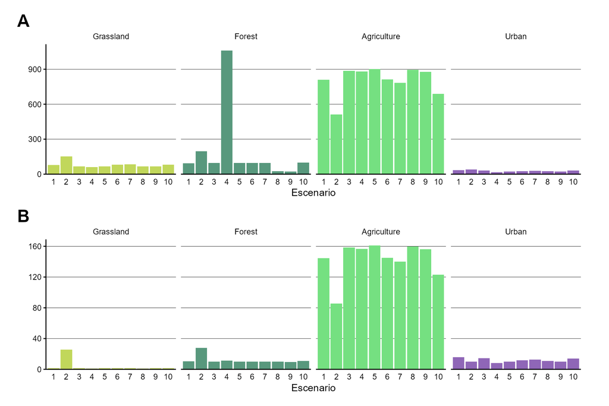

Cantidades, en miles, de nitrógeno (**A**) y fósforo (**B**) por clase y escenario

**Ver código**

```r
nutri_files <- list.files(
  path = "datos/",
  pattern = "^nutriente",
  full.names = TRUE
)[1:4]
nutri_tbl <- read_csv(nutri_files, show_col_types = FALSE)

area_clase_tbl <- read_csv("datos/area_por_clase.csv", show_col_types = FALSE)
area_clase_tbl2 <- area_clase_tbl |>
  mutate(tipo = factor(tipo, clases_orden))

f_gg_nutriente_por <- function(X) {
  g <- nutri_tbl |>
    mutate(tipo = fct_reorder(tipo, sum)) |>
    mutate(
      porcentaje = sum / sum(sum),
      .by = c(esc, prod)
    ) |>
    arrange(tipo) |>
    mutate(esc = factor(esc)) |>
    mutate(fraccion = sum / sum(sum), .by = c(esc, prod)) |>
    filter(prod == X) |>
    mutate(tipo = factor(tipo, clases_orden)) |>
    ggplot(aes(esc, fraccion, fill = tipo)) +
    geom_col(show.legend = FALSE) +
    geom_hline(
      data = area_clase_tbl2,
      aes(yintercept = area_prop),
      color = "black",
      linetype = 2,
      linewidth = .4
    ) +
    geom_label(
      data = area_clase_tbl2,
      aes(
        label = paste0(format(area_prop * 100, digits = 2), "%"),
        y = area_prop,
        x = 10
      ),
      vjust = -.1,
      hjust = .5,
      size = 2,
      fill = alpha("white", .5),
      label.size = unit(0, "mm"),
      inherit.aes = FALSE
    ) +
    facet_wrap(vars(tipo), nrow = 1, scales = "free") +
    scale_y_continuous(
      labels = scales::label_percent(),
      expand = expansion(mult = c(0, .1), add = c(0, 0))
    ) +
    scale_fill_manual(
      breaks = clases_orden,
      values = clases_color
    ) +
    coord_cartesian(clip = "off") +
    labs(x = "Escenario") +
    theme_classic(base_size = 7) +
    theme(
      aspect.ratio = 1,
      plot.background = element_blank(),
      axis.ticks = element_line(color = "black"),
      axis.ticks.x = element_blank(),
      axis.title.y = element_blank(),
      axis.text = element_text(color = "black"),
      axis.text.x = element_text(margin = margin(t = 1)),
      axis.text.y = element_text(hjust = 1),
      panel.spacing.x = unit(8, "pt"),
      panel.ontop = FALSE,
      panel.background = element_blank(),
      panel.grid.minor = element_blank(),
      panel.grid.major.y = element_line(color = "black", linewidth = .1),
      panel.grid.major.x = element_blank(),
      strip.background = element_blank(),
      strip.text = element_text(color = "black")
    )

  ggsave(
    plot = g,
    filename = paste0("figuras/", X, "_por.png"),
    width = 15,
    height = 4.25,
    units = "cm"
  )
}

f_gg_nutriente_por("n_total_export")
f_gg_nutriente_por("p_surface_export")
```

Porcentaje de nitrógeno aportado por clase, por escenario, comparado con la proporción del área de la clase.

**NotaMostrar imagen**

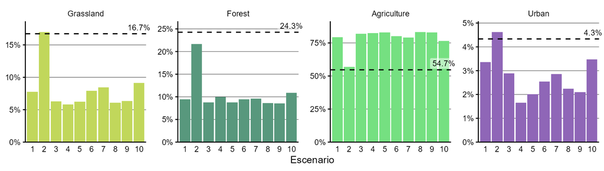

Figura 6: Procentaje de nitrógeno por clase y escenario.

Porcentaje de fósforo aportado por clase, por escenario, comparado con la proporción del área de la clase.

**NotaMostrar imagen**

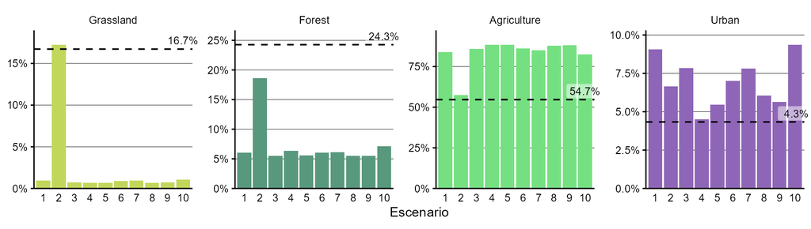

Figura 7: Procentaje de fósforo por clase y escenario.

La siguiente figura combina las figuras individuales para nitrógeno (Figura 6) y fósforo (Figura 7).

**Ver código**

```r
g_nutriente_porc <- nutri_tbl |>
  mutate(tipo = fct_reorder(tipo, sum)) |>
  mutate(
    porcentaje = sum / sum(sum),
    .by = c(esc, prod)
  ) |>
  arrange(tipo) |>
  mutate(esc = factor(esc)) |>
  mutate(fraccion = sum / sum(sum), .by = c(esc, prod)) |>
  filter(prod %in% c("n_total_export", "p_surface_export")) |>
  mutate(tipo = factor(tipo, clases_orden)) |>
  ggplot(aes(esc, fraccion, fill = prod)) +
  geom_col(position = position_dodge()) +
  geom_hline(
    data = area_clase_tbl2,
    aes(yintercept = area_prop),
    color = "black",
    linetype = 2,
    linewidth = .4
  ) +
  geom_label(
    data = area_clase_tbl2,
    aes(
      label = paste0(format(area_prop * 100, digits = 2), "%"),
      y = area_prop,
      x = 10
    ),
    vjust = -.1,
    hjust = .5,
    size = 2,
    fill = alpha("white", .5),
    label.size = unit(0, "mm"),
    inherit.aes = FALSE
  ) +
  facet_wrap(vars(tipo), nrow = 1, scales = "free") +
  scale_y_continuous(
    labels = scales::label_percent(),
    expand = expansion(mult = c(0, .1), add = c(0, 0))
  ) +
  scale_fill_manual(
    breaks = c("n_total_export", "p_surface_export"),
    labels = c("N", "P"),
    values = c("#4FB6CA", "#E3C28B")
  ) +
  coord_cartesian(clip = "off") +
  labs(x = "Escenario", fill = NULL) +
  theme_classic(base_size = 7) +
  theme(
    aspect.ratio = 1,
    plot.background = element_blank(),
    axis.ticks = element_line(color = "black"),
    axis.ticks.x = element_blank(),
    axis.title.y = element_blank(),
    axis.text = element_text(color = "black"),
    axis.text.x = element_text(margin = margin(t = 1)),
    axis.text.y = element_text(hjust = 1),
    panel.spacing.x = unit(8, "pt"),
    panel.ontop = FALSE,
    panel.background = element_blank(),
    panel.grid.minor = element_blank(),
    panel.grid.major.y = element_line(color = "black", linewidth = .1),
    panel.grid.major.x = element_blank(),
    strip.background = element_blank(),
    strip.text = element_text(color = "black"),
    legend.position = "top",
    legend.background = element_blank(),
    legend.key.size = unit(.3, "cm"),
    legend.box.spacing = unit(0, "mm"),
    legend.text = element_text(
      margin = margin(r = 10, l = 2),
      size = rel(.8)
    )
  )

ggsave(
  plot = g_nutriente_porc,
  filename = "figuras/nutriente_compuesto_porcentaje.png",
  width = 15,
  height = 4.7,
  units = "cm"
)
```

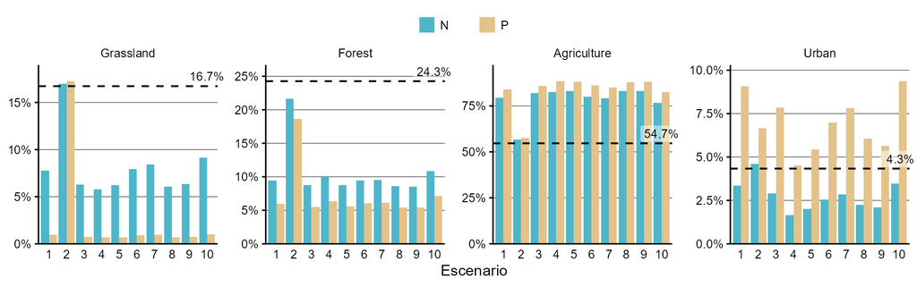

Figura 8: Porcentajes de nutrientes N y P, por clase y escenario, comparado con la cobertura de cada clase

Índice $NDRi$ para nitrógeno, en millones.

**Ver código**

```r
ndri_valor <- readxl::read_xlsx("datos/ndri_nutri.xlsx") |>
  janitor::clean_names() |>
  select(nutriente, esc, forest, grassland, agriculture, urban) |>
  mutate(esc = str_remove(esc, "SCENARIO ")) |>
  mutate(esc = as.numeric(esc)) |>
  pivot_longer(
    cols = -c(esc, nutriente),
    values_to = "ndri",
    names_to = "tipo"
  ) |>
  mutate(tipo = str_to_sentence(tipo)) |>
  mutate(tipo = factor(tipo, clases_orden)) |>
  mutate(esc = factor(esc)) |>
  mutate(
    suma = sum(ndri),
    .by = c(nutriente, esc)
  ) |>
  mutate(
    prop = ndri / suma
  )

f_gg_ndri <- function(X) {
  g <- ndri_valor |>
    filter(nutriente == X) |>
    ggplot(aes(esc, ndri, fill = tipo)) +
    geom_col(show.legend = FALSE) +
    facet_wrap(vars(tipo), nrow = 1, scales = "free") +
    scale_y_continuous(
      labels = scales::label_number(
        scale = 1e-6,
        decimal.mark = ".",
        big.mark = ","
      ),
      expand = expansion(add = c(0, 0), mult = c(0, .05))
    ) +
    scale_fill_manual(
      breaks = clases_orden,
      values = clases_color
    ) +
    labs(x = "Escenario") +
    theme_classic(base_size = 7) +
    theme(
      aspect.ratio = 1,
      plot.background = element_blank(),
      axis.ticks = element_line(color = "black"),
      axis.ticks.x = element_blank(),
      axis.title.y = element_blank(),
      axis.text = element_text(color = "black"),
      axis.text.y = element_text(hjust = 1),
      panel.background = element_blank(),
      panel.grid.minor = element_blank(),
      panel.grid.major.y = element_line(color = "black", linewidth = .1),
      panel.grid.major.x = element_blank(),
      strip.background = element_blank(),
      strip.text = element_text(color = "black")
    )

  ggsave(
    plot = g,
    filename = paste0("figuras/ndri_", X, ".png"),
    width = 15,
    height = 4.25,
    units = "cm"
  )
}

f_gg_ndri("N")
f_gg_ndri("P")
```

**NotaMostrar imagen**

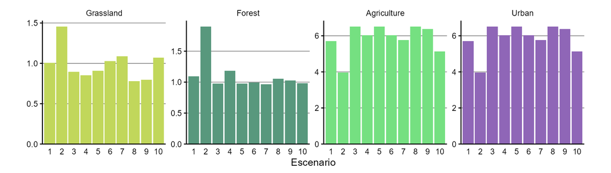

Figura 9: NDRi por clase y escenario para nitrógeno

Índice $NDRi$ para fósforo, en millones.

**NotaMostrar imagen**

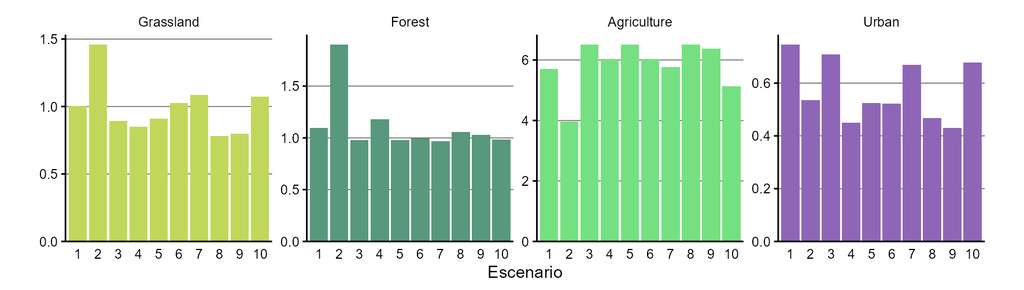

Figura 10: NDRi por clase y escenario para fósforo

Combinando las figuras 9 y 10 se generó la siguiente, en millones, del $NDRi$ para nitrógeno (**A**) y fósforo (**B**), por clase y escenario.

**Ver código**

```r
f_gg_ndri <- function(X) {
  ndri_valor |>
    filter(nutriente == X) |>
    ggplot(aes(esc, ndri, fill = tipo)) +
    geom_col(show.legend = FALSE) +
    facet_wrap(vars(tipo), nrow = 1, scales = "free") +
    scale_y_continuous(
      labels = scales::label_number(
        scale = 1e-6,
        decimal.mark = ".",
        big.mark = ","
      ),
      expand = expansion(add = c(0, 0), mult = c(0, .05))
    ) +
    scale_fill_manual(
      breaks = clases_orden,
      values = clases_color
    ) +
    labs(x = "Escenario") +
    theme_classic(base_size = 7) +
    theme(
      aspect.ratio = 1,
      plot.background = element_blank(),
      axis.ticks = element_line(color = "black"),
      axis.ticks.x = element_blank(),
      axis.title.y = element_blank(),
      axis.text = element_text(color = "black"),
      axis.text.y = element_text(hjust = 1),
      panel.background = element_blank(),
      panel.grid.minor = element_blank(),
      panel.grid.major.y = element_line(color = "black", linewidth = .1),
      panel.grid.major.x = element_blank(),
      strip.background = element_blank(),
      strip.text = element_text(color = "black")
    )
}

fig_ndri1 <- f_gg_ndri("N")
fig_ndri2 <- f_gg_ndri("P")

fig_ndri3 <- (fig_ndri1 / fig_ndri2) +
  plot_annotation(
    tag_levels = "A"
  ) &
  theme(
    plot.background = element_blank(),
    plot.tag.position = "topleft",
    plot.tag.location = "margin",
    plot.tag = element_text(
      size = 12,
      margin = margin(b = 0, r = -15),
      face = "bold"
    )
  )

ggsave(
  plot = fig_ndri3,
  filename = "figuras/ndri_compuesto.png",
  width = 15,
  height = 10,
  units = "cm"
)
```

**Ejes verticales individuales**

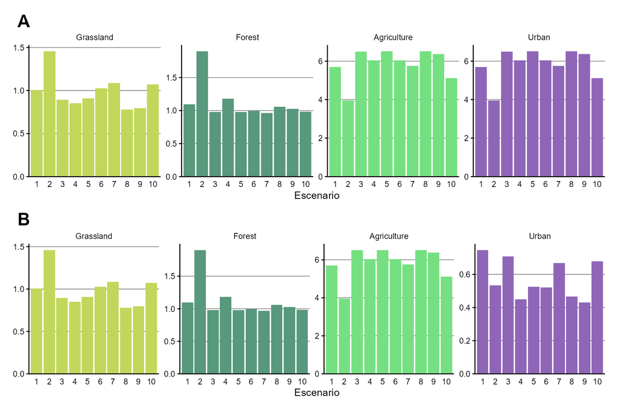

Figura 11: Índice NDRi para nitrógeno y fósforo, por clase y escenario.

**Eje vertical compartido**

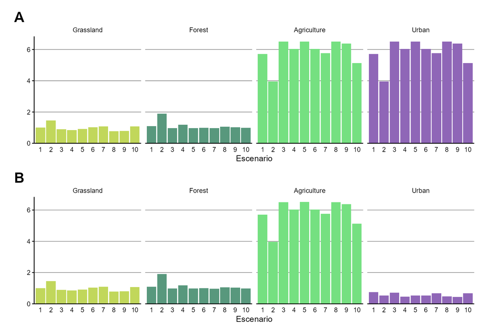

Índice NDRi para nitrógeno y fósforo, por clase y escenario.

**Ver código**

```r
f_gg_ndri_porcentaje <- function(X) {
  g <- ndri_valor |>
    filter(nutriente == X) |>
    ggplot(aes(esc, prop, fill = tipo)) +
    geom_col(show.legend = FALSE) +
    geom_hline(
      data = area_clase_tbl2,
      aes(yintercept = area_prop),
      color = "black",
      linetype = 2,
      linewidth = .4
    ) +
    geom_label(
      data = area_clase_tbl2,
      aes(
        label = paste0(format(area_prop * 100, digits = 2), "%"),
        y = area_prop,
        x = 10
      ),
      vjust = -.1,
      hjust = .5,
      size = 2,
      fill = alpha("white", .5),
      label.size = unit(0, "mm"),
      inherit.aes = FALSE
    ) +
    facet_wrap(vars(tipo), nrow = 1, scales = "free") +
    scale_y_continuous(
      labels = scales::label_percent(),
      expand = expansion(add = c(0, 0), mult = c(0, .05))
    ) +
    scale_fill_manual(
      breaks = clases_orden,
      values = clases_color
    ) +
    coord_cartesian(clip = "off") +
    labs(x = "Escenario") +
    theme_classic(base_size = 7) +
    theme(
      aspect.ratio = 1,
      plot.background = element_blank(),
      axis.ticks = element_line(color = "black"),
      axis.ticks.x = element_blank(),
      axis.title.y = element_blank(),
      axis.text = element_text(color = "black"),
      axis.text.y = element_text(hjust = 1),
      panel.background = element_blank(),
      panel.grid.minor = element_blank(),
      panel.grid.major.y = element_line(color = "black", linewidth = .1),
      panel.grid.major.x = element_blank(),
      strip.background = element_blank(),
      strip.text = element_text(color = "black")
    )

  ggsave(
    plot = g,
    filename = paste0("figuras/ndri_", X, "_porcentaje.png"),
    width = 15,
    height = 4.25,
    units = "cm"
  )
}

f_gg_ndri_porcentaje("N")
f_gg_ndri_porcentaje("P")
```

Porcentaje del indice $NDRi$ para nitrógeno, asociado a cada clase, comparado con la cobertura de la misma (línea horizontal).

**NotaMostrar imagen**

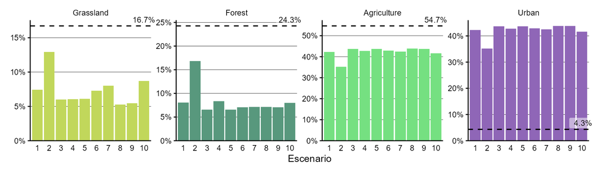

Figura 12: Porcenataje de NDRi asociado a cada clase y escenario para nitrógeno

Porcentaje del indice $NDRi$ para fósforo, asociado a cada clase, comparado con la cobertura de la misma (línea horizontal).

**NotaMostrar imagen**

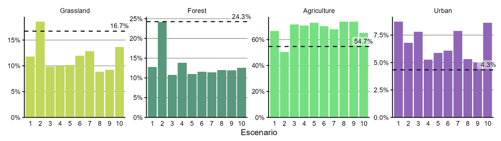

Figura 13: Porcenataje de NDRi asociado a cada clase y escenario para fósforo

La siguiente figura combina los porcentajes de $NDRi$ para nitrógeno (Figura 12) y fósforo (Figura 13), por clase y escenario, comparado con la cobertura de la clase (línea de trazos horizontal).

**Ver código**

```r
g_ndri <- ndri_valor |>
  ggplot(aes(esc, prop, fill = nutriente)) +
  geom_col(position = position_dodge(), show.legend = TRUE) +
  geom_hline(
    data = area_clase_tbl2,
    aes(yintercept = area_prop),
    color = "black",
    linetype = 2,
    linewidth = .4
  ) +
  geom_label(
    data = area_clase_tbl2,
    aes(
      label = paste0(format(area_prop * 100, digits = 2), "%"),
      y = area_prop,
      x = Inf
    ),
    vjust = -.1,
    hjust = 1,
    size = 2,
    fill = alpha("white", .8),
    label.size = unit(0, "mm"),
    label.padding = unit(0, "mm"),
    label.r = unit(0, "mm"),
    inherit.aes = FALSE
  ) +
  facet_wrap(vars(tipo), nrow = 1, scales = "free") +
  scale_y_continuous(
    labels = scales::label_percent(),
    expand = expansion(add = c(0, 0), mult = c(0, .05))
  ) +
  scale_fill_manual(
    breaks = c("N", "P"),
    values = c("#4FB6CA", "#E3C28B")
  ) +
  coord_cartesian(clip = "off") +
  labs(x = "Escenario", fill = NULL) +
  theme_classic(base_size = 7) +
  theme(
    aspect.ratio = 1,
    plot.background = element_blank(),
    axis.ticks = element_line(color = "black"),
    axis.ticks.x = element_blank(),
    axis.title.y = element_blank(),
    axis.text = element_text(color = "black"),
    axis.text.y = element_text(hjust = 1),
    panel.background = element_blank(),
    panel.grid.minor = element_blank(),
    panel.grid.major.y = element_line(color = "black", linewidth = .1),
    panel.grid.major.x = element_blank(),
    panel.spacing.x = unit(12, "pt"),
    strip.background = element_blank(),
    strip.text = element_text(color = "black"),
    legend.position = "top",
    legend.background = element_blank(),
    legend.key.size = unit(.3, "cm"),
    legend.box.spacing = unit(0, "mm"),
    legend.text = element_text(
      margin = margin(r = 10, l = 2),
      size = rel(.8)
    )
  )

ggsave(
  plot = g,
  filename = "figuras/ndri_compuesto_porcentaje.png",
  width = 15,
  height = 4.7,
  units = "cm"
)
```

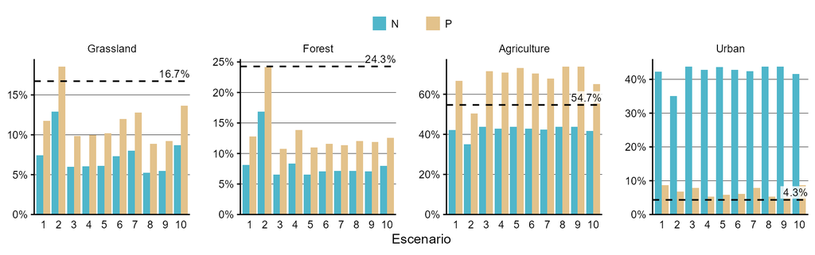

Figura 14: Porcenataje de NDRi asociado a cada clase y escenario para nutrientes N y P

**Ver código**

```r
m_conect_lulc <- read_csv("datos/m_conect_lulc.csv", show_col_types = FALSE) |>
  rename(metric_lulc = metric)

m_conect_lulc |>
  pivot_wider(
    names_from = tipo,
    values_from = metric_lulc
  ) |>
  gt() |>
  sub_missing() |>
  fmt_auto(
    columns = c(max_d, CCP)
  ) |>
  fmt_number(
    columns = c(LCP, CPL, IIC),
    decimals = 1,
    drop_trailing_zeros = TRUE
  ) |>
  fmt_engineering(
    columns = c(SLC, MSC, ECS, AWF),
    exp_style = "E1",
    decimals = 1
  ) |>
  cols_label(
    max_d = "Distancia Máx."
  ) |>
  tab_style(
    locations = cells_body(),
    style = cell_text(font = "JetBrains Mono")
  ) |>
  tab_source_note(
    source_note = md(
      glue(
        "Datos (.csv) disponibles para su [descarga {bsicons::bs_icon('download')} ](https://raw.githubusercontent.com/vhgauto/paisaje/refs/heads/main/datos/m_conect_lulc.csv)"
      )
    )
  ) |>
  cols_label(
    max_d = "Distancia Máx."
  ) |>
  tab_options(
    table.border.top.style = "hidden",
    table.width = 1000,
    table.background.color = "transparent"
  ) |>
  as_raw_html()
```

Tabla 1: Métricas de conectividad para escenario original.

| Distancia Máx. | NC | LNK | SLC | MSC | CCP | LCP | CPL | ECS | AWF | IIC |
| --- | --- | --- | --- | --- | --- | --- | --- | --- | --- | --- |
| 0 | 6 | 0 | 6.6E9 | 1.1E9 | 1 | 0.2 | — | 6.6E9 | — | 0 |
| 10 | 5 | 1 | 6.6E9 | 1.3E9 | 1 | 0.2 | — | 6.6E9 | 4.6E12 | 0 |
| 100 | 2 | 5 | 6.6E9 | 3.3E9 | 1 | 0.2 | 1.6 | 6.6E9 | 165.5E12 | 0.2 |
| 1,000 | 1 | 6 | 6.6E9 | 6.6E9 | 1 | 0.2 | 1.7 | 6.6E9 | 1.6E15 | 0.2 |
| 10,000 | 1 | 8 | 6.6E9 | 6.6E9 | 1 | 0.2 | 1.9 | 6.6E9 | 2.1E15 | 0.2 |
| 100,000 | 1 | 16 | 6.6E9 | 6.6E9 | 1 | 0.2 | 1.3 | 6.6E9 | 2.1E15 | 0.2 |

Datos (.csv) disponibles para su [descarga](https://raw.githubusercontent.com/vhgauto/paisaje/refs/heads/main/datos/m_conect_lulc.csv)

Las métricas de conectividad por escenario resultaron idénticas, por lo que los escenarios no se muestran en la siguiente tabla.

**Ver código**

```r
m_conect <- read_csv("datos/m_conect.csv", show_col_types = FALSE)

m_conect |>
  mutate(esc = paste0("Esc. ", esc)) |>
  reframe(
    m = mean(metric),
    .by = c(max_d, tipo)
  ) |>
  pivot_wider(
    names_from = tipo,
    values_from = m
  ) |>
  gt() |>
  sub_missing() |>
  fmt_auto(
    columns = c(max_d, CCP)
  ) |>
  fmt_number(
    columns = c(LCP, CPL, IIC),
    decimals = 1,
    drop_trailing_zeros = TRUE
  ) |>
  fmt_engineering(
    columns = c(SLC, MSC, ECS, AWF),
    decimals = 1,
    exp_style = "E1"
  ) |>
  cols_label(
    max_d = "Distancia Máx."
  ) |>
  tab_style(
    locations = cells_body(),
    style = cell_text(font = "JetBrains Mono")
  ) |>
  tab_source_note(
    source_note = md(
      glue(
        "Datos (.csv) disponibles para su [descarga {bsicons::bs_icon('download')} ](https://raw.githubusercontent.com/vhgauto/paisaje/refs/heads/main/datos/m_conect.csv)"
      )
    )
  ) |>
  tab_options(
    table.border.top.style = "hidden",
    table.background.color = "transparent",
    table.width = 1000
  ) |>
  as_raw_html()
```

Tabla 2: Métricas de conectividad por escenario y distancia máxima.

| Distancia Máx. | NC | LNK | SLC | MSC | CCP | LCP | CPL | ECS | AWF | IIC |
| --- | --- | --- | --- | --- | --- | --- | --- | --- | --- | --- |
| 0 | 6 | 0 | 6.6E9 | 1.1E9 | 1 | 0.2 | — | 6.6E9 | — | 0 |
| 10 | 5 | 2 | 6.6E9 | 1.3E9 | 1 | 0.2 | 1 | 6.6E9 | 4.6E12 | 0.2 |
| 100 | 2 | 5 | 6.6E9 | 3.3E9 | 1 | 0.2 | 1.6 | 6.6E9 | 165.4E12 | 0.2 |
| 1,000 | 1 | 6 | 6.6E9 | 6.6E9 | 1 | 0.2 | 1.7 | 6.6E9 | 1.6E15 | 0.2 |
| 10,000 | 1 | 8 | 6.6E9 | 6.6E9 | 1 | 0.2 | 1.9 | 6.6E9 | 2.1E15 | 0.2 |
| 100,000 | 1 | 16 | 6.6E9 | 6.6E9 | 1 | 0.2 | 1.3 | 6.6E9 | 2.1E15 | 0.2 |

Datos (.csv) disponibles para su [descarga](https://raw.githubusercontent.com/vhgauto/paisaje/refs/heads/main/datos/m_conect.csv)

# 1 Lectura de datos

El paquete usado es [`{rflsgen}`](https://dimitri-justeau.github.io/rflsgen/), **Neutral Landscape Generator with Targets on Landscape Indices**.

**Precaución**

Antes que nada hay que ejecutar los siguientes comandos:

```r
options(
  java.parameters = c("-XX:+UseConcMarkSweepGC", "-Xmx36g")
)
gc()
```

Esto permite aumentar la memoria disponible para las funciones de `{rflsgen}`.

Los paquetes usados son los siguientes:

```r
library(tidyverse)
library(glue)
library(gt)
library(landscapemetrics)
library(NLMR)
library(rflsgen)
library(patchwork)
library(terra)
```

Inicialmente hay que leer los ráster de uso de suelo (`r`) y modelo digital de elevación (`dem`).

**Ver código**

```r
r <- rast("datos/r.tif")
dem <- rast("datos/dem.tif")
```

Las clases de `r` son:

Tabla 1.1: Clases y valores asignados.

| Valor | Tipo |
| --- | --- |
| 0 | No data |
| 10 | Forest |
| 20 | Scrubland |
| 30 | Grassland |
| 40 | Agriculture |
| 50 | Urban |
| 60 | Sparse vegetation - bare soil |
| 80 | Water body |

Agrego las categorías a `r` e incorporo colores. Visualizo ambos ráster.

**Ver código**

```r
d <- read_delim(
  file = "datos/LULCcode.txt",
  delim = "$ ",
  col_names = c("value"),
  show_col_types = FALSE
) |>
  separate_wider_delim(
    delim = " ",
    cols = value,
    names = c("value", "tipo"),
    too_many = "merge"
  ) |>
  mutate(value = as.integer(value)) |>
  filter(value != 0) |>
  mutate(
    col = c(
      "#58987D",
      "#377EB8",
      "#C1D75B",
      "#75E081",
      "#8F66B7",
      "#A65628",
      "#F781BF"
    )
  )

col_df <- d |>
  select(-tipo) |>
  as.data.frame()

# incorporo categorías y colores
levels(r) <- d
coltab(r) <- col_df
```

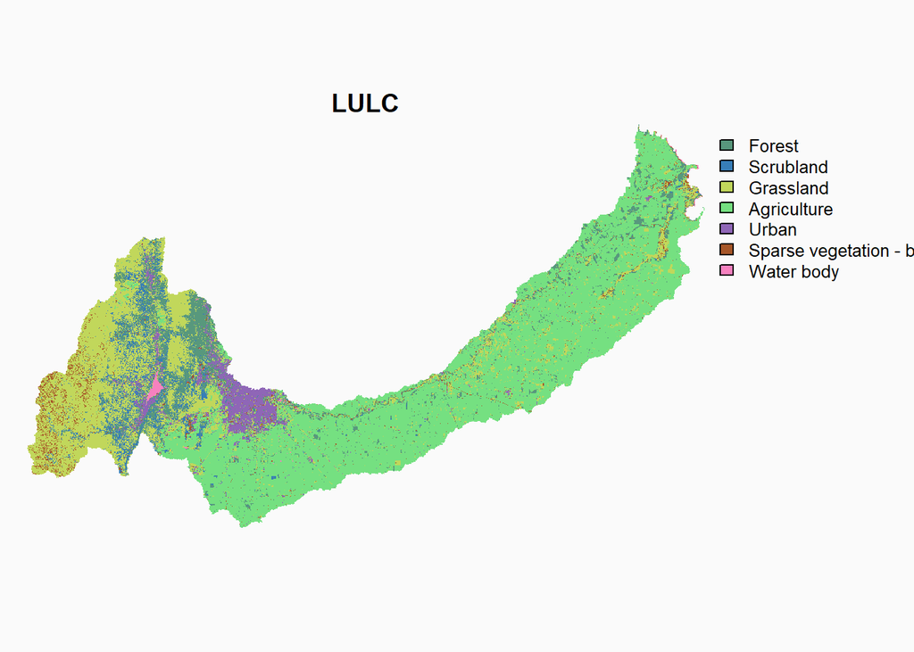

Mapa de clases

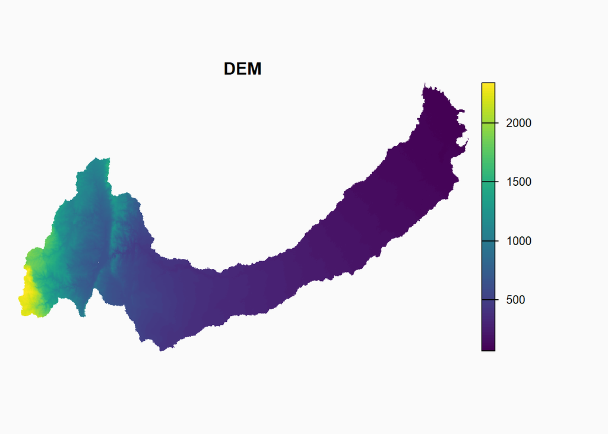

Mapa de modelo digital de elevación

Figura 1.1: Mapas de la región de interés.

# 2 Extracción de la estructura del paisaje

Se seleccionan las clases de interés del ráster de cobertura del suelo.

**Ver código**

```r
clases <- c(30, 40, 50) # Grassland, Agriculture, Urban

estructura <- flsgen_extract_structure_from_raster(
  raster_file = r,
  focal_classes = clases,
  connectivity = 8
)
```

A partir de `estructura` y `dem` se genera un paisaje, indicando dependencia del terreno, conectividad, rugosidad y parámetros de posición.

Para visualizar el efecto de la dependencia del terreno (`terrain_dependency`) se generan 10 escenarios con valores crecientes entre 0,1 y 1,0.

**Ver código**

```r
f_dependencia <- function(x) {
  print(paste0("Dependencia del terreno: ", x))

  r_land <- flsgen_generate(
    estructura,
    terrain_file = dem,
    terrain_dependency = x,
    connectivity = 8,
    epsg = "EPSG:22174",
    resolution_x = res(r)[1],
    resolution_y = res(r)[2],
    x = ext(dem)$"xmin",
    y = ext(dem)$"ymax"
  )

  writeRaster(r_land, filename = paste0("rasters/land-", x, ".tif"))
}

dependencias <- seq(.1, 1, .1)
walk(dependencias, f_dependencia)
```

Se muestran a continuación los escenarios para las dependencias del terreno 0,1, 0,3, 0,7 y 1,0.

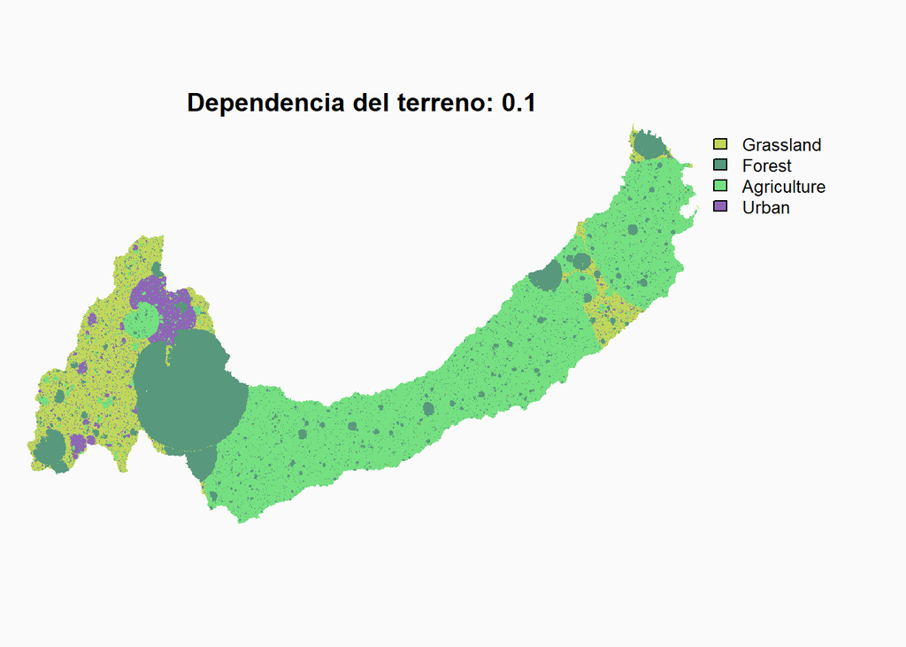

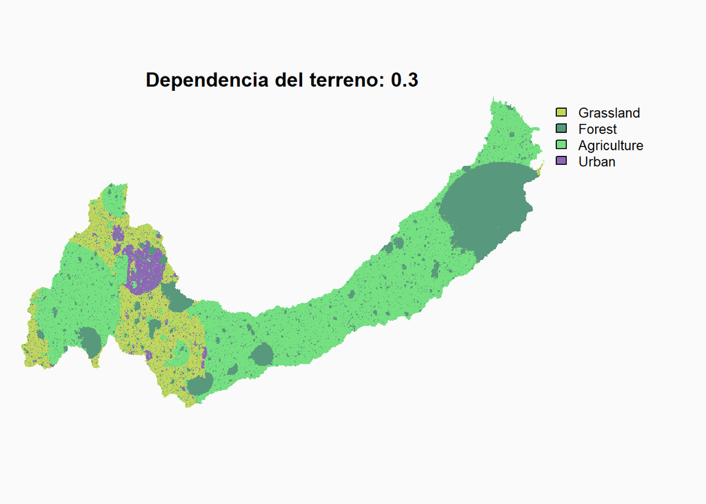

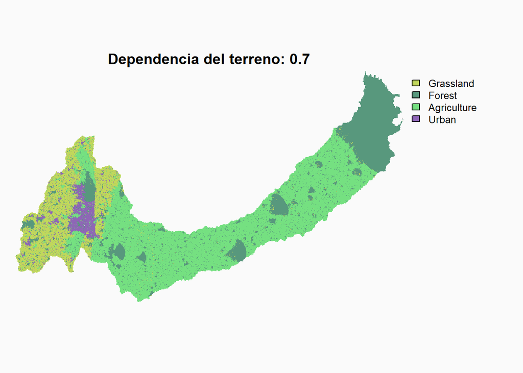

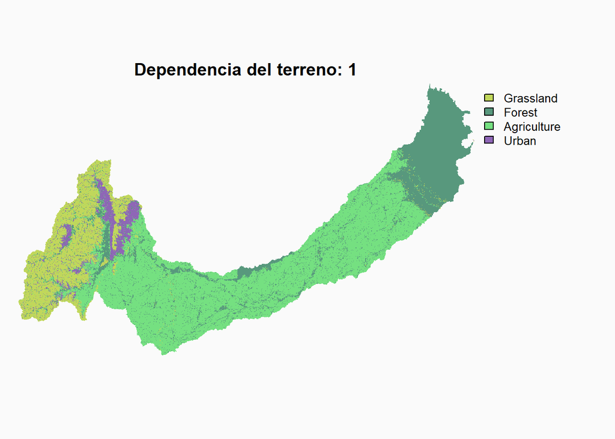

Figura 2.1: Mapa de clases para una selección de dependencias del terreno.

El paquete `{rflsgen}` genera múltiples escenarios pero manteniendo constantes las métricas del paisaje.

En la generación de los escenarios pueden suceder dos errores:

- **Falta de memoria**, al no contar con la suficiente capacidad de procesamiento. Para solucionarlo se puede reducir el tamaño de la región de interés, aumentar el tamaño de píxel o disminuir el número de clases.
- **Incapacidad de generar el ráster**, mostrando el siguiente mensaje:

```r
Could not generate a raster satisfying the input landscape structure
```

Esto puede solucionarse eligiendo únicamente las clases de interés.

# 3 Cálculo de métricas del paisaje

Para el cálculo de las métricas se utiliza el paquete [`{landscapemetrics}`](https://r-spatialecology.github.io/landscapemetrics/).

Las métricas se dividen clase y paisaje. A continuación se muestran los resultados para las clases originales y luego para los diferentes escenarios, considerando todas las dependencias del terreno.

**Ver código**

```r
funcion_generica_clase <- function(raster, funcion) {
  i <- which(funciones_clase == funcion)
  print(paste0(i, "/", length(funciones_clase)))
  print(funcion)
  ff <- eval(str2lang(funcion))
  ff(raster)
}

funciones_clase <- ls("package:landscapemetrics")[
  str_detect(ls("package:landscapemetrics"), "lsm_c")
]
funciones_clase <- funciones_clase[!str_detect(funciones_clase, "_cv|_sd")]

# elimino: 'lsm_c_enn_mn'
funciones_clase <- funciones_clase[funciones_clase != "lsm_c_enn_mn"]
# 32 funciones

funcion_generica_paisaje <- function(raster, funcion) {
  i <- which(funciones_paisaje == funcion)
  print(paste0(i, "/", length(funciones_paisaje)))
  print(funcion)
  ff <- eval(str2lang(funcion))
  ff(raster)
}

funciones_paisaje <- ls("package:landscapemetrics")[
  str_detect(ls("package:landscapemetrics"), "lsm_l")
]
funciones_paisaje <- funciones_paisaje[
  !str_detect(funciones_paisaje, "_cv|_sd")
]

funciones_paisaje <- funciones_paisaje[funciones_paisaje != "lsm_l_enn_mn"]
# 43 funciones

f_contenido_funcion <- function(x) {
  tools::Rd_db("landscapemetrics")[[paste0("lsm_c_", x, ".Rd")]] |>
    as.character()
}

f_contenido_funcion2 <- function(x) {
  tools::Rd_db("landscapemetrics")[[paste0("lsm_l_", x, ".Rd")]] |>
    as.character()
}

# funciones auxiliares para las tablas con {gt}
f_titulo_funcion <- function(x) {
  if (str_count(x, "\\(") == 1) {
    r <- str_trim(str_replace(x, " \\(.*?\\)", ""))
  } #else {
  #   r <- str_trim(str_extract(x, "^.*?\\(.*?\\)[^()]*")) # OK
  # }

  if (str_count(x, "\\(") == 2) {
    r <- str_trim(str_extract(x, "^.*?\\(.*?\\)[^()]*"))
  }

  if (str_count(x, "\\(") == 0) {
    r <- str_trim(x)
  }

  return(r)
}

f_eq <- function(x) {
  id_eq <- which(x == "\\deqn") + 3
  x[id_eq]
}
```

## 3.1 Métricas de clase y paisaje para LULC

**Ver código**

```r
f_loop_clase_lulc <- function() {
  map2(
    .x = r,
    .y = funciones_clase,
    ~ funcion_generica_clase(raster = .x, funcion = .y),
    .progress = TRUE
  ) |>
    list_rbind()
}

metrica_clase_lulc <- f_loop_clase_lulc() # 53M
metrica_clase_lulc |>
  rename(clase = class) |>
  full_join(rename(d, clase = value), by = join_by(clase)) |>
  select(-c(col, id, level, layer)) |>
  write_csv("datos/metrica_clase_lulc.csv")

f_loop_paisaje_lulc <- function() {
  map2(
    .x = r,
    .y = funciones_paisaje,
    ~ funcion_generica_paisaje(raster = .x, funcion = .y),
    .progress = TRUE
  ) |>
    list_rbind()
}

metrica_paisaje_lulc <- f_loop_paisaje_lulc() # 54M
metrica_paisaje_lulc |>
  select(metric, value) |>
  write_csv("datos/metrica_paisaje_lulc.csv")
```

Tabla con métricas a nivel de **clase** obteniendo un valor para cada clase de uso del suelo.

**Ver código**

```r
read_csv("datos/metrica_clase_lulc.csv", show_col_types = FALSE) |>
  pivot_wider(
    names_from = tipo,
    values_from = value,
    id_cols = metric
  ) |>
  mutate(
    txt = map(metric, f_contenido_funcion)
  ) |>
  mutate(
    titulo = map_chr(txt, ~ .x[16])
  ) |>
  mutate(titulo = map_chr(titulo, f_titulo_funcion)) |>
  mutate(
    link = paste0(
      "https://r-spatialecology.github.io/landscapemetrics/reference/lsm_c_",
      metric,
      ".html"
    )
  ) |>
  mutate(
    titulo = glue::glue("[{titulo}]({link})")
  ) |>
  select(Métrica = titulo, Forest:`Water body`) |>
  arrange(Métrica) |>
  gt() |>
  fmt_auto(
    columns = Forest:`Water body`,
    locale = "es"
  ) |>
  tab_style(
    locations = cells_body(columns = Forest:`Water body`),
    style = cell_text(font = "JetBrains Mono", color = "black")
  ) |>
  tab_style(
    locations = cells_body(columns = c(Métrica)),
    style = cell_text(align = "left")
  ) |>
  cols_label(
    `Sparse vegetation - bare soil` = html("Sparse vegetation<br>Bare soil")
  ) |>
  fmt_url(columns = Métrica, color = "#8E063B") |>
  tab_source_note(
    source_note = md(
      glue(
        "Datos (.csv) disponibles para su [descarga {bsicons::bs_icon('download')} ](https://raw.githubusercontent.com/vhgauto/paisaje/refs/heads/main/datos/metrica_clase_lulc.csv)"
      )
    )
  ) |>
  tab_options(
    table.background.color = "transparent"
  ) |>
  as_raw_html()
```

Tabla 3.1: Métricas de clase, escenario original.

| Métrica | Forest | Scrubland | Grassland | Agriculture | Urban | Sparse vegetation Bare soil | Water body |
| --- | --- | --- | --- | --- | --- | --- | --- |
| [Aggregation index](https://r-spatialecology.github.io/landscapemetrics/reference/lsm_c_ai.html) | 92,826 | 86,222 | 94,512 | 98,837 | 92,42 | 80,212 | 95,553 |
| [Clumpiness index](https://r-spatialecology.github.io/landscapemetrics/reference/lsm_c_clumpy.html) | 0,921 | 0,856 | 0,928 | 0,974 | 0,921 | 0,797 | 0,955 |
| [Core area percentage of landscape](https://r-spatialecology.github.io/landscapemetrics/reference/lsm_c_cpland.html) | 7,272 | 2,383 | 19,725 | 52,406 | 3,231 | 0,935 | 0,309 |
| [Disjunct core area density](https://r-spatialecology.github.io/landscapemetrics/reference/lsm_c_dcad.html) | 4,353 | 5,657 | 7,995 | 2,237 | 2,602 | 6,402 | 0,137 |
| [Edge Density](https://r-spatialecology.github.io/landscapemetrics/reference/lsm_c_ed.html) | 27,663 | 23,861 | 53,082 | 24,941 | 13,167 | 19,094 | 0,633 |
| [Effective Mesh Size](https://r-spatialecology.github.io/landscapemetrics/reference/lsm_c_mesh.html) | 266,91 | 3,284 | 11.194,37 | 108.247,679 | 454,133 | 0,241 | 3,295 |
| [Interspersion and Juxtaposition index](https://r-spatialecology.github.io/landscapemetrics/reference/lsm_c_iji.html) | 83,251 | 59,143 | 86,911 | 68,98 | 84,688 | 66,713 | 87,162 |
| [Landscape division index](https://r-spatialecology.github.io/landscapemetrics/reference/lsm_c_division.html) | 1 | 1 | 0,983 | 0,837 | 0,999 | 1 | 1 |
| [Landscape shape index](https://r-spatialecology.github.io/landscapemetrics/reference/lsm_c_lsi.html) | 182,431 | 234,296 | 221,395 | 71,092 | 129,575 | 251,426 | 22,865 |
| [Largest patch index](https://r-spatialecology.github.io/landscapemetrics/reference/lsm_c_lpi.html) | 1,917 | 0,104 | 12,821 | 38,491 | 2,593 | 0,018 | 0,222 |
| [Mean fractal dimension index](https://r-spatialecology.github.io/landscapemetrics/reference/lsm_c_frac_mn.html) | 1,046 | 1,044 | 1,042 | 1,039 | 1,042 | 1,037 | 1,056 |
| [Mean number of disjunct core areas](https://r-spatialecology.github.io/landscapemetrics/reference/lsm_c_dcore_mn.html) | 1,097 | 1,115 | 1,159 | 1,209 | 1,13 | 0,972 | 1,18 |
| [Mean of Contiguity index](https://r-spatialecology.github.io/landscapemetrics/reference/lsm_c_contig_mn.html) | 0,675 | 0,636 | 0,634 | 0,63 | 0,622 | 0,615 | 0,701 |
| [Mean of core area index](https://r-spatialecology.github.io/landscapemetrics/reference/lsm_c_cai_mn.html) | 24,909 | 18,045 | 17,762 | 17,206 | 15,173 | 14,297 | 29,718 |
| [Mean of core area](https://r-spatialecology.github.io/landscapemetrics/reference/lsm_c_core_mn.html) | 1,832 | 0,47 | 2,859 | 28,312 | 1,403 | 0,142 | 2,661 |
| [Mean of patch area](https://r-spatialecology.github.io/landscapemetrics/reference/lsm_c_area_mn.html) | 2,426 | 0,851 | 3,518 | 29,537 | 1,882 | 0,366 | 3,154 |
| [Mean of related circumscribing circle](https://r-spatialecology.github.io/landscapemetrics/reference/lsm_c_circle_mn.html) | 0,521 | 0,505 | 0,506 | 0,497 | 0,511 | 0,494 | 0,564 |
| [Mean perimeter-area ratio](https://r-spatialecology.github.io/landscapemetrics/reference/lsm_c_para_mn.html) | 0,106 | 0,119 | 0,12 | 0,121 | 0,124 | 0,126 | 0,097 |
| [Mean radius of gyration](https://r-spatialecology.github.io/landscapemetrics/reference/lsm_c_gyrate_mn.html) | 36,098 | 27,019 | 27,852 | 29,802 | 24,879 | 21,627 | 45,238 |
| [Mean shape index](https://r-spatialecology.github.io/landscapemetrics/reference/lsm_c_shape_mn.html) | 1,304 | 1,295 | 1,276 | 1,244 | 1,264 | 1,222 | 1,354 |
| [Normalized landscape shape index](https://r-spatialecology.github.io/landscapemetrics/reference/lsm_c_nlsi.html) | 0,072 | 0,138 | 0,055 | 0,014 | 0,076 | 0,198 | 0,044 |
| [Number of disjunct core areas](https://r-spatialecology.github.io/landscapemetrics/reference/lsm_c_ndca.html) | 28.945 | 37.617 | 53.164 | 14.875 | 17.300 | 42.567 | 910 |
| [Number of patches](https://r-spatialecology.github.io/landscapemetrics/reference/lsm_c_np.html) | 26.390 | 33.732 | 45.871 | 12.308 | 15.311 | 43.806 | 771 |
| [Patch Cohesion Index](https://r-spatialecology.github.io/landscapemetrics/reference/lsm_c_cohesion.html) | 99,44 | 97,508 | 99,918 | 99,98 | 99,767 | 93,287 | 98,411 |
| [Patch density](https://r-spatialecology.github.io/landscapemetrics/reference/lsm_c_pd.html) | 3,969 | 5,073 | 6,899 | 1,851 | 2,303 | 6,588 | 0,116 |
| [Percentage of Like Adjacencies](https://r-spatialecology.github.io/landscapemetrics/reference/lsm_c_pladj.html) | 92,789 | 86,171 | 94,488 | 98,821 | 92,366 | 80,148 | 95,359 |
| [Percentage of landscape of class](https://r-spatialecology.github.io/landscapemetrics/reference/lsm_c_pland.html) | 9,628 | 4,319 | 24,266 | 54,675 | 4,333 | 2,413 | 0,366 |
| [Perimeter-Area Fractal Dimension](https://r-spatialecology.github.io/landscapemetrics/reference/lsm_c_pafrac.html) | 1,382 | 1,487 | 1,45 | 1,435 | 1,532 | 1,515 | 1,358 |
| [Splitting index](https://r-spatialecology.github.io/landscapemetrics/reference/lsm_c_split.html) | 2.491,2 | 202.443,946 | 59,398 | 6,143 | 1.464,166 | 2,759 × 10<sup>6</sup> | 201.818,734 |
| [Total (class) area](https://r-spatialecology.github.io/landscapemetrics/reference/lsm_c_ca.html) | 64.020,26 | 28.717,59 | 161.353,18 | 363.546,06 | 28.810,5 | 16.046,87 | 2.431,46 |
| [Total (class) edge](https://r-spatialecology.github.io/landscapemetrics/reference/lsm_c_te.html) | 1,839 × 10<sup>7</sup> | 1,587 × 10<sup>7</sup> | 3,530 × 10<sup>7</sup> | 1,658 × 10<sup>7</sup> | 8,755 × 10<sup>6</sup> | 1,270 × 10<sup>7</sup> | 420.930 |
| [Total core area](https://r-spatialecology.github.io/landscapemetrics/reference/lsm_c_tca.html) | 48.353,47 | 15.842,47 | 131.155,8 | 348.462,4 | 21.484,4 | 6.215,27 | 2.051,51 |

Datos (.csv) disponibles para su [descarga](https://raw.githubusercontent.com/vhgauto/paisaje/refs/heads/main/datos/metrica_clase_lulc.csv)

Tabla con métricas a nivel de **paisaje** para todo el ráster de uso del suelo.

**Ver código**

```r
read_csv("datos/metrica_paisaje_lulc.csv", show_col_types = FALSE) |>
  mutate(
    txt = map(metric, f_contenido_funcion2)
  ) |>
  mutate(
    titulo = map_chr(txt, ~ .x[16])
  ) |>
  mutate(titulo = map_chr(titulo, f_titulo_funcion)) |>
  mutate(
    link = paste0(
      "https://r-spatialecology.github.io/landscapemetrics/reference/lsm_l_",
      metric,
      ".html"
    )
  ) |>
  mutate(
    titulo = glue::glue("[{titulo}]({link})")
  ) |>
  select(Métrica = titulo, Valor = value) |>
  arrange(Métrica) |>
  gt() |>
  fmt_auto(
    columns = Valor,
    locale = "es"
  ) |>
  tab_style(
    locations = cells_body(columns = Valor),
    style = cell_text(font = "JetBrains Mono", color = "black")
  ) |>
  tab_style(
    locations = cells_body(columns = c(Métrica)),
    style = cell_text(align = "left")
  ) |>
  fmt_url(columns = Métrica, color = "#8E063B") |>
  tab_source_note(
    source_note = md(
      glue(
        "Datos (.csv) disponibles para su [descarga {bsicons::bs_icon('download')} ](https://raw.githubusercontent.com/vhgauto/paisaje/refs/heads/main/datos/metrica_paisaje_lulc.csv)"
      )
    )
  ) |>
  tab_options(
    table.background.color = "transparent"
  ) |>
  as_raw_html()
```

Tabla 3.2: Métricas del paisaje, escenario original.

| Métrica | Valor |
| --- | --- |
| [Aggregation index](https://r-spatialecology.github.io/landscapemetrics/reference/lsm_l_ai.html) | 95,924 |
| [Conditional entropy \[H(y\|x)\]](https://r-spatialecology.github.io/landscapemetrics/reference/lsm_l_condent.html) | 0,3 |
| [Contagion](https://r-spatialecology.github.io/landscapemetrics/reference/lsm_l_contag.html) | 61,734 |
| [Disjunct core area density](https://r-spatialecology.github.io/landscapemetrics/reference/lsm_l_dcad.html) | 29,383 |
| [Edge Density](https://r-spatialecology.github.io/landscapemetrics/reference/lsm_l_ed.html) | 81,221 |
| [Effective Mesh Size](https://r-spatialecology.github.io/landscapemetrics/reference/lsm_l_mesh.html) | 120.169,912 |
| [Interspersion and Juxtaposition index](https://r-spatialecology.github.io/landscapemetrics/reference/lsm_l_iji.html) | 78,768 |
| [Joint entropy \[H(x, y)\]](https://r-spatialecology.github.io/landscapemetrics/reference/lsm_l_joinent.html) | 2,149 |
| [Landscape division index](https://r-spatialecology.github.io/landscapemetrics/reference/lsm_l_division.html) | 0,819 |
| [Landscape shape index](https://r-spatialecology.github.io/landscapemetrics/reference/lsm_l_lsi.html) | 168,792 |
| [Largest patch index](https://r-spatialecology.github.io/landscapemetrics/reference/lsm_l_lpi.html) | 38,491 |
| [Marginal entropy \[H(x)\]](https://r-spatialecology.github.io/landscapemetrics/reference/lsm_l_ent.html) | 1,848 |
| [Mean fractal dimension index](https://r-spatialecology.github.io/landscapemetrics/reference/lsm_l_frac_mn.html) | 1,042 |
| [Mean number of disjunct core areas](https://r-spatialecology.github.io/landscapemetrics/reference/lsm_l_dcore_mn.html) | 1,096 |
| [Mean of Contiguity index](https://r-spatialecology.github.io/landscapemetrics/reference/lsm_l_contig_mn.html) | 0,635 |
| [Mean of core area index](https://r-spatialecology.github.io/landscapemetrics/reference/lsm_l_cai_mn.html) | 17,813 |
| [Mean of core area](https://r-spatialecology.github.io/landscapemetrics/reference/lsm_l_core_mn.html) | 3,219 |
| [Mean of patch area](https://r-spatialecology.github.io/landscapemetrics/reference/lsm_l_area_mn.html) | 3,732 |
| [Mean of related circumscribing circle](https://r-spatialecology.github.io/landscapemetrics/reference/lsm_l_circle_mn.html) | 0,505 |
| [Mean perimeter-area ratio](https://r-spatialecology.github.io/landscapemetrics/reference/lsm_l_para_mn.html) | 0,12 |
| [Mean radius of gyration](https://r-spatialecology.github.io/landscapemetrics/reference/lsm_l_gyrate_mn.html) | 27,34 |
| [Mean shape index](https://r-spatialecology.github.io/landscapemetrics/reference/lsm_l_shape_mn.html) | 1,267 |
| [Modified Simpson's diversity index](https://r-spatialecology.github.io/landscapemetrics/reference/lsm_l_msidi.html) | 0,99 |
| [Modified Simpson's evenness index](https://r-spatialecology.github.io/landscapemetrics/reference/lsm_l_msiei.html) | 0,509 |
| [Mutual information \[I(y,x)\]](https://r-spatialecology.github.io/landscapemetrics/reference/lsm_l_mutinf.html) | 1,548 |
| [Number of disjunct core areas](https://r-spatialecology.github.io/landscapemetrics/reference/lsm_l_ndca.html) | 195.378 |
| [Number of patches](https://r-spatialecology.github.io/landscapemetrics/reference/lsm_l_np.html) | 178.189 |
| [Patch Cohesion Index](https://r-spatialecology.github.io/landscapemetrics/reference/lsm_l_cohesion.html) | 99,902 |
| [Patch density](https://r-spatialecology.github.io/landscapemetrics/reference/lsm_l_pd.html) | 26,798 |
| [Patch richness density](https://r-spatialecology.github.io/landscapemetrics/reference/lsm_l_prd.html) | 0,001 |
| [Patch richness](https://r-spatialecology.github.io/landscapemetrics/reference/lsm_l_pr.html) | 7 |
| [Percentage of Like Adjacencies](https://r-spatialecology.github.io/landscapemetrics/reference/lsm_l_pladj.html) | 95,937 |
| [Perimeter-Area Fractal Dimension](https://r-spatialecology.github.io/landscapemetrics/reference/lsm_l_pafrac.html) | 1,454 |
| [Relative mutual information](https://r-spatialecology.github.io/landscapemetrics/reference/lsm_l_relmutinf.html) | 0,838 |
| [Relative patch richness](https://r-spatialecology.github.io/landscapemetrics/reference/lsm_l_rpr.html) | NA |
| [Shannon's diversity index](https://r-spatialecology.github.io/landscapemetrics/reference/lsm_l_shdi.html) | 1,281 |
| [Shannons's evenness index](https://r-spatialecology.github.io/landscapemetrics/reference/lsm_l_shei.html) | 0,658 |
| [Simpson's diversity index](https://r-spatialecology.github.io/landscapemetrics/reference/lsm_l_sidi.html) | 0,629 |
| [Simpson's evenness index](https://r-spatialecology.github.io/landscapemetrics/reference/lsm_l_siei.html) | 0,733 |
| [Splitting index](https://r-spatialecology.github.io/landscapemetrics/reference/lsm_l_split.html) | 5,533 |
| [Total area](https://r-spatialecology.github.io/landscapemetrics/reference/lsm_l_ta.html) | 664.925,92 |
| [Total core area](https://r-spatialecology.github.io/landscapemetrics/reference/lsm_l_tca.html) | 573.565,32 |
| [Total edge](https://r-spatialecology.github.io/landscapemetrics/reference/lsm_l_te.html) | 5,401 × 10<sup>7</sup> |

Datos (.csv) disponibles para su [descarga](https://raw.githubusercontent.com/vhgauto/paisaje/refs/heads/main/datos/metrica_paisaje_lulc.csv)

## 3.2 Métricas a nivel de clase

Las métricas del paisaje a nivel de clase devuelven un valor asociado a cada categoría del ráster de interés.

Se calcularon en total 32 métricas de clase. Las métricas que son independientes de las dependencias del terreno se muestran en la siguiente tabla.

**Ver código**

```r
m_clase |>
  filter(as.numeric(metric) <= 12) |>
  reframe(
    v = median(valor),
    .by = c(tipo, metric)
  ) |>
  pivot_wider(
    names_from = tipo,
    values_from = v
  ) |>
  mutate(
    txt = map(metric, f_contenido_funcion)
  ) |>
  mutate(
    titulo = map_chr(txt, ~ .x[16])
  ) |>
  mutate(
    eq = map_chr(txt, f_eq)
  ) |>
  mutate(eq = paste0("$$", eq, "$$")) |>
  mutate(titulo = map_chr(titulo, f_titulo_funcion)) |>
  mutate(
    link = paste0(
      "https://r-spatialecology.github.io/landscapemetrics/reference/lsm_c_",
      metric,
      ".html"
    )
  ) |>
  mutate(
    titulo = glue::glue("[{titulo}]({link})")
  ) |>
  select(Métrica = titulo, Grassland, Forest, Agriculture, Urban) |>
  arrange(Métrica) |>
  gt() |>
  fmt_auto(
    columns = c(Grassland, Forest, Agriculture, Urban),
    locale = "es"
  ) |>
  tab_style(
    locations = cells_body(columns = c(Grassland, Forest, Agriculture, Urban)),
    style = cell_text(font = "JetBrains Mono", color = "black")
  ) |>
  tab_style(
    locations = cells_body(columns = c(Métrica)),
    style = cell_text(align = "left")
  ) |>
  fmt_url(columns = Métrica, color = "#8E063B") |>
  tab_source_note(
    source_note = md(
      glue(
        "Datos (.csv) disponibles para su [descarga {bsicons::bs_icon('download')} ](https://raw.githubusercontent.com/vhgauto/paisaje/refs/heads/main/datos/métricas_X_cla.csv)"
      )
    )
  ) |>
  tab_options(
    table.background.color = "transparent"
  ) |>
  as_raw_html()
```

Tabla 3.3: Métricas de clase independientes de la dependencia del terreno.

| Métrica | Grassland | Forest | Agriculture | Urban |
| --- | --- | --- | --- | --- |
| [Core area percentage of landscape](https://r-spatialecology.github.io/landscapemetrics/reference/lsm_c_cpland.html) | 14,477 | 21,281 | 51,803 | 3,416 |
| [Effective Mesh Size](https://r-spatialecology.github.io/landscapemetrics/reference/lsm_c_mesh.html) | 11.424,251 | 11.194,37 | 108.247,679 | 454,133 |
| [Landscape division index](https://r-spatialecology.github.io/landscapemetrics/reference/lsm_c_division.html) | 0,983 | 0,983 | 0,837 | 0,999 |
| [Largest patch index](https://r-spatialecology.github.io/landscapemetrics/reference/lsm_c_lpi.html) | 12,864 | 12,821 | 38,491 | 2,593 |
| [Mean of core area](https://r-spatialecology.github.io/landscapemetrics/reference/lsm_c_core_mn.html) | 0,91 | 3,085 | 27,986 | 1,483 |
| [Mean of patch area](https://r-spatialecology.github.io/landscapemetrics/reference/lsm_c_area_mn.html) | 1,049 | 3,518 | 29,537 | 1,882 |
| [Number of patches](https://r-spatialecology.github.io/landscapemetrics/reference/lsm_c_np.html) | 106.352 | 45.871 | 12.308 | 15.311 |
| [Patch density](https://r-spatialecology.github.io/landscapemetrics/reference/lsm_c_pd.html) | 15,995 | 6,899 | 1,851 | 2,303 |
| [Percentage of landscape of class](https://r-spatialecology.github.io/landscapemetrics/reference/lsm_c_pland.html) | 16,726 | 24,266 | 54,675 | 4,333 |
| [Splitting index](https://r-spatialecology.github.io/landscapemetrics/reference/lsm_c_split.html) | 58,203 | 59,398 | 6,143 | 1.464,166 |
| [Total (class) area](https://r-spatialecology.github.io/landscapemetrics/reference/lsm_c_ca.html) | 111.216,18 | 161.353,18 | 363.546,06 | 28.810,5 |
| [Total core area](https://r-spatialecology.github.io/landscapemetrics/reference/lsm_c_tca.html) | 96.258,72 | 141.504,76 | 344.449,525 | 22.713,325 |

Datos (.csv) disponibles para su [descarga](https://raw.githubusercontent.com/vhgauto/paisaje/refs/heads/main/datos/m%C3%A9tricas_X_cla.csv)

La métricas de clase que mostraron cambios con la dependencia del terreno se observan en la figura de líneas.

**Ver código**

```r
g1 <- m_clase |>
  filter(as.numeric(metric) > 12) |>
  nest(.by = metric) |>
  mutate(
    txt = map(metric, f_contenido_funcion)
  ) |>
  mutate(
    titulo = map_chr(txt, ~ .x[16])
  ) |>
  mutate(titulo = map_chr(titulo, f_titulo_funcion)) |>
  mutate(titulo = str_wrap(titulo, 17)) |>
  unnest(data) |>
  mutate(titulo = fct_reorder(titulo, as.numeric(metric))) |>
  ggplot(aes(dependencia_terreno, valor, color = tipo, group = tipo)) +
  geom_line(alpha = .8) +
  facet_wrap(vars(titulo), scales = "free", ncol = 10) +
  scale_x_continuous(
    breaks = seq(.1, 1, .1),
    labels = c("0,1", "", "", "", "", "", "", "", "", "1"),
    expand = c(0, 0),
    name = NULL
  ) +
  scale_y_continuous(
    name = NULL,
    labels = scales::label_number(big.mark = ".", decimal.mark = ",")
  ) +
  scale_color_manual(
    name = NULL,
    breaks = d_r$tipo,
    values = d_r$col
  ) +
  guides(
    color = guide_legend(override.aes = list(linewidth = 2))
  ) +
  theme_bw(base_size = 10, base_family = "Lato") +
  theme(
    aspect.ratio = 1,
    plot.margin = margin(r = 10),
    plot.background = element_blank(),
    panel.background = element_blank(),
    panel.spacing.x = unit(10, "pt"),
    panel.grid.minor = element_blank(),
    panel.grid.major = element_line(linewidth = .1, color = "grey"),
    legend.position = "top",
    legend.background = element_blank(),
    legend.text = element_text(margin = margin(r = 10)),
    axis.text = element_text(size = rel(.6), color = "black"),
    axis.ticks = element_blank(),
    axis.text.y = element_text(margin = margin(r = 0)),
    strip.text = element_text(face = "bold", hjust = 0, size = rel(.7)),
    strip.background = element_blank(),
    strip.clip = "off"
  )

ggsave(
  plot = g1,
  filename = "figuras/metricas_clase_dif.png",
  width = 30,
  height = 8.5,
  units = "cm"
)
```

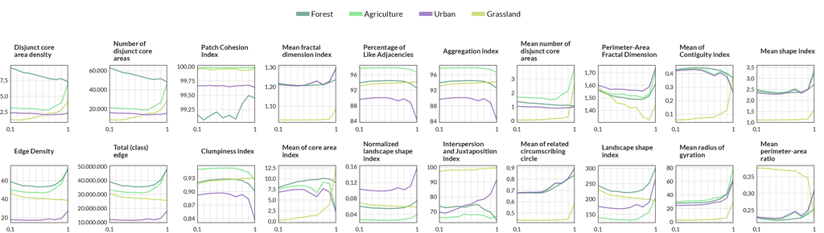

Figura 3.1: Métricas de clase variables con la dependencia del terreno.

## 3.3 Métricas a nivel de paisaje

A partir de los diez escenarios creados con diferentes dependencias del terreno, se calcularon 43 métricas del paisaje.

Se muestra a continuación una tabla que resume los valores de las métricas que se mantuvieron constantes, mostrando un único valor por cada métrica.

**Ver código**

```r
m_paisaje |>
  filter(as.numeric(metric) <= 10) |>
  reframe(
    v = median(valor),
    .by = metric
  ) |>
  mutate(
    txt = map(metric, f_contenido_funcion2)
  ) |>
  mutate(
    titulo = map_chr(txt, ~ .x[16])
  ) |>
  mutate(
    eq = map_chr(txt, f_eq)
  ) |>
  mutate(eq = paste0("$$", eq, "$$")) |>
  mutate(titulo = map_chr(titulo, f_titulo_funcion)) |>
  mutate(
    link = paste0(
      "https://r-spatialecology.github.io/landscapemetrics/reference/lsm_l_",
      metric,
      ".html"
    )
  ) |>
  mutate(
    titulo = glue::glue("[{titulo}]({link})")
  ) |>
  select(Métrica = titulo, Valor = v) |>
  arrange(Métrica) |>
  gt() |>
  fmt_auto(
    columns = Valor,
    locale = "es"
  ) |>
  tab_style(
    locations = cells_body(columns = Valor),
    style = cell_text(font = "JetBrains Mono", color = "black")
  ) |>
  tab_style(
    locations = cells_body(columns = c(Métrica)),
    style = cell_text(align = "left")
  ) |>
  fmt_url(columns = Métrica, color = "#8E063B") |>
  tab_source_note(
    source_note = md(
      glue(
        "Datos (.csv) disponibles para su [descarga {bsicons::bs_icon('download')} ](https://raw.githubusercontent.com/vhgauto/paisaje/refs/heads/main/datos/métricas_X_pai.csv)"
      )
    )
  ) |>
  tab_options(
    table.background.color = "transparent"
  ) |>
  as_raw_html()
```

Tabla 3.4: Métricas de paisaje independientes de la dependencia del terreno.

| Métrica | Valor |
| --- | --- |
| [Largest patch index](https://r-spatialecology.github.io/landscapemetrics/reference/lsm_l_lpi.html) | 38,491 |
| [Modified Simpson's diversity index](https://r-spatialecology.github.io/landscapemetrics/reference/lsm_l_msidi.html) | 0,948 |
| [Modified Simpson's evenness index](https://r-spatialecology.github.io/landscapemetrics/reference/lsm_l_msiei.html) | 0,684 |
| [Patch richness density](https://r-spatialecology.github.io/landscapemetrics/reference/lsm_l_prd.html) | 6,016 × 10<sup>−4</sup> |
| [Patch richness](https://r-spatialecology.github.io/landscapemetrics/reference/lsm_l_pr.html) | 4 |
| [Shannon's diversity index](https://r-spatialecology.github.io/landscapemetrics/reference/lsm_l_shdi.html) | 1,109 |
| [Shannons's evenness index](https://r-spatialecology.github.io/landscapemetrics/reference/lsm_l_shei.html) | 0,8 |
| [Simpson's diversity index](https://r-spatialecology.github.io/landscapemetrics/reference/lsm_l_sidi.html) | 0,612 |
| [Simpson's evenness index](https://r-spatialecology.github.io/landscapemetrics/reference/lsm_l_siei.html) | 0,816 |
| [Total area](https://r-spatialecology.github.io/landscapemetrics/reference/lsm_l_ta.html) | 664.925,92 |

Datos (.csv) disponibles para su [descarga](https://raw.githubusercontent.com/vhgauto/paisaje/refs/heads/main/datos/m%C3%A9tricas_X_pai.csv)

Con las métricas del paisaje que varían con la dependencia del terreno se creó la siguiente figura.

**Ver código**

```r
g2 <- m_paisaje |>
  filter(as.numeric(metric) > 10) |>
  nest(.by = metric) |>
  mutate(
    txt = map(metric, f_contenido_funcion2)
  ) |>
  mutate(
    titulo = map_chr(txt, ~ .x[16])
  ) |>
  mutate(titulo = map_chr(titulo, f_titulo_funcion)) |>
  mutate(titulo = str_wrap(titulo, 17)) |>
  unnest(data) |>
  mutate(titulo = fct_reorder(titulo, as.numeric(metric))) |>
  ggplot(aes(dependencia_terreno, valor, group = metric)) +
  geom_line(alpha = .8, color = "#8E063B") +
  facet_wrap(vars(titulo), scales = "free", ncol = 8) +
  scale_x_continuous(
    breaks = seq(.1, 1, .1),
    labels = c("0,1", "", "", "", "", "", "", "", "", "1"),
    expand = c(0, 0),
    name = NULL
  ) +
  scale_y_continuous(
    name = NULL,
    labels = scales::label_number(big.mark = ".", decimal.mark = ",")
  ) +
  scale_color_manual(name = NULL) +
  guides(
    color = guide_legend(override.aes = list(linewidth = 2))
  ) +
  theme_bw(base_size = 10, base_family = "Lato") +
  theme(
    aspect.ratio = 1,
    plot.margin = margin(r = 10),
    plot.background = element_blank(),
    panel.background = element_blank(),
    panel.spacing.x = unit(10, "pt"),
    panel.grid.minor = element_blank(),
    panel.grid.major = element_line(linewidth = .1, color = "grey"),
    legend.position = "bottom",
    legend.text = element_text(margin = margin(r = 10)),
    axis.text = element_text(size = rel(.6), color = "black"),
    axis.ticks = element_blank(),
    axis.text.y = element_text(margin = margin(r = 0)),
    strip.text = element_text(face = "bold", hjust = 0, size = rel(.7)),
    strip.background = element_blank(),
    strip.clip = "off"
  )

ggsave(
  plot = g2,
  filename = "figuras/metricas_paisaje_dif.png",
  width = 30,
  height = 17,
  units = "cm"
)
```

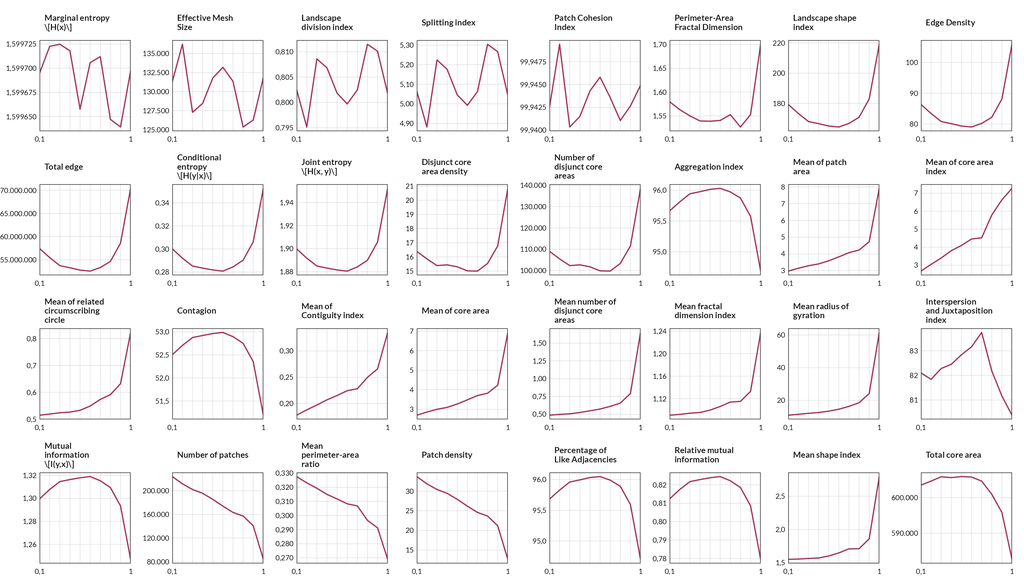

Figura 3.2: Métricas de paisaje variables con la dependencia del terreno.

# 4 Estructura del paisaje propia

Genero el **caso I** y el **caso II**, cada uno con dos clases y métricas del paisaje diferentes.

Luego, para verificar los escenarios generados, calculo las métricas y verifico que se cumplan las condiciones dadas.

[Defino](https://dimitri-justeau.github.io/rflsgen/reference/flsgen_create_class_targets.html) dos clases y sus métricas.

**Ver código**

```r
tibble(
  Clase = c("Clase 1", "Clase 2"),
  `Number of patches` = c("[700, 800]", "[800, 1100]"),
  `Patch area` = c("[5500, 14600]", "[9500, 11060]"),
  `Proportion of landscape` = c("10%", "-")
) |>
  gt() |>
  cols_label(
    `Number of patches` = md("Number of<br>patches"),
    `Proportion of landscape` = md("Proportion of<br>landscape"),
    "Clase" = ""
  ) |>
  tab_style(
    locations = cells_body(columns = -Clase),
    style = cell_text(font = "JetBrains Mono", color = "black")
  ) |>
  tab_header(title = md("**Caso I**")) |>
  tab_options(
    table.background.color = "transparent"
  )
```

Tabla 4.1: Características del paisaje para el Caso I.

**Caso I**

|  | Number of patches | Patch area | Proportion of landscape |
| --- | --- | --- | --- |
| Clase 1 | [700, 800] | [5500, 14600] | 10% |
| Clase 2 | [800, 1100] | [9500, 11060] | - |

**Ver código**

```r
tibble(
  Clase = c("Clase A", "Clase B"),
  `Number of patches` = c("[700, 800]", "[700, 800]"),
  `Patch area` = c("[15500, 114600]", "[15500, 114600]"),
  `Proportion of landscape` = c("-", "25%")
) |>
  gt() |>
  cols_label(
    `Number of patches` = md("Number of<br>patches"),
    `Proportion of landscape` = md("Proportion of<br>landscape"),
    "Clase" = ""
  ) |>
  tab_style(
    locations = cells_body(columns = -Clase),
    style = cell_text(font = "JetBrains Mono", color = "black")
  ) |>
  tab_header(title = md("**Caso II**")) |>
  tab_options(
    table.background.color = "transparent"
  )
```

Tabla 4.2: Características del paisaje para el Caso II.

**Caso II**

|  | Number of patches | Patch area | Proportion of landscape |
| --- | --- | --- | --- |
| Clase A | [700, 800] | [15500, 114600] | - |
| Clase B | [700, 800] | [15500, 114600] | 25% |

```r
# CASO I
cls_1 <- flsgen_create_class_targets(
  class_name = "Clase 1",
  NP = c(700, 800),
  AREA = c(5500, 14600),
  PLAND = c(10, 10)
)

cls_2 <- flsgen_create_class_targets(
  class_name = "Clase 2",
  NP = c(800, 1100),
  AREA = c(9500, 11060)
)

# CASO II
cls_A <- flsgen_create_class_targets(
  class_name = "Clase A",
  NP = c(700, 800),
  AREA = c(15500, 114600)
)

cls_B <- flsgen_create_class_targets(
  class_name = "Clase B",
  NP = c(700, 800),
  AREA = c(15500, 114600)
)
```

Las métricas y los valores tienen que ser coherentes y no pueden adoptar cualquier número. En caso de indicar valores incorrectos, se muestra el siguiente mensaje de error:

```r
User targets cannot be satisfied
```

[Creo](https://dimitri-justeau.github.io/rflsgen/reference/flsgen_create_landscape_targets.html) un conjunto con las clases y obtengo la estructura, utilizando el `dem` como máscara.

**Ver código**

```r
# CASO I
objetivos <- flsgen_create_landscape_targets(
  mask_raster = dem,
  classes = list(cls_1, cls_2)
)

estructura_custom <- flsgen_structure(objetivos)

# CASO II
objetivos2 <- flsgen_create_landscape_targets(
  mask_raster = dem,
  classes = list(cls_A, cls_B)
)

estructura_custom2 <- flsgen_structure(objetivos2)
```

Genero un ráster a partir de las clases creadas y su estructura ubicados sobre el `dem` original.

**Ver código**

```r
r_custom <- flsgen_generate(
  estructura_custom,
  terrain_file = dem,
  terrain_dependency = 1,
  connectivity = 8,
  epsg = "EPSG:22174",
  resolution_x = res(r)[1],
  resolution_y = res(r)[2],
  x = ext(dem)$"xmin",
  y = ext(dem)$"ymax"
)

writeRaster(r_custom, "rasters/r_custom.tif", overwrite = TRUE)

r_custom2 <- flsgen_generate(
  estructura_custom2,
  terrain_file = dem,
  terrain_dependency = 1,
  connectivity = 8,
  epsg = "EPSG:22174",
  resolution_x = res(r)[1],
  resolution_y = res(r)[2],
  x = ext(dem)$"xmin",
  y = ext(dem)$"ymax"
)

writeRaster(r_custom2, "rasters/r_custom2.tif", overwrite = TRUE)
```

Visualizo los resultados de ambos casos.

**Ver código**

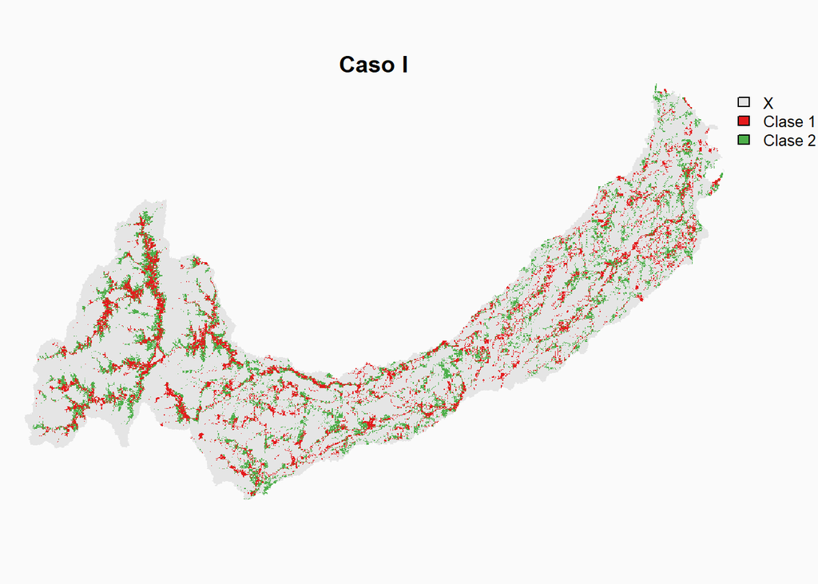

Mapa de clases para el Caso I

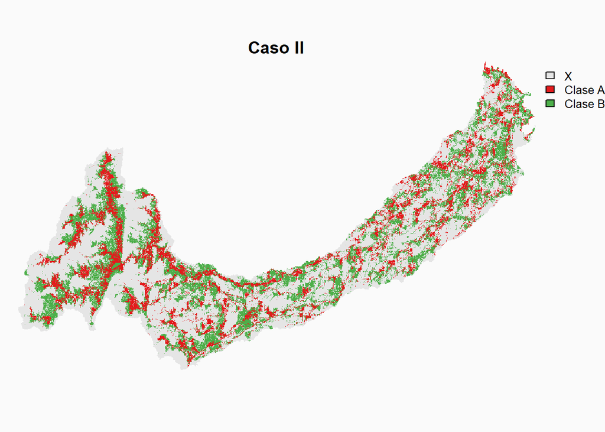

Mapa de clases para el Caso II

Figura 4.1: Mapas correspondientes a escenarios con métricas definidas.

```r
r_custom <- rast("rasters/r_custom.tif")

d_custom <- tibble(
  value = as.integer(c(0, 1)),
  tipo = c("Clase 1", "Clase 2"),
  col = c("#E41A1C", "#4DAF4A")
) |>
  add_row(
    value = as.integer(-1),
    tipo = "X",
    col = "grey90"
  )

col_df_custom <- d_custom |>
  select(-tipo) |>
  as.data.frame()

# incorporo categorías y colores
levels(r_custom) <- d_custom
coltab(r_custom) <- col_df_custom

par(bg = "#FAFAFA")

plot(
  r_custom,
  axes = FALSE,
  mar = c(1, 1, 1, 4),
  main = "Caso I",
  background = "#FAFAFA"
)
r_custom2 <- rast("rasters/r_custom2.tif")

d_custom2 <- tibble(
  value = as.integer(c(0, 1)),
  tipo = c("Clase A", "Clase B"),
  col = c("#E41A1C", "#4DAF4A")
) |>
  add_row(
    value = as.integer(-1),
    tipo = "X",
    col = "grey90"
  )

col_df_custom2 <- d_custom2 |>
  select(-tipo) |>
  as.data.frame()

# incorporo categorías y colores
levels(r_custom2) <- d_custom2
coltab(r_custom2) <- col_df_custom2

plot(
  r_custom2,
  axes = FALSE,
  mar = c(1, 1, 1, 4),
  main = "Caso II",
  background = "#FAFAFA"
)
```

Verifico que el ráster creado tenga las métricas previamente definidas para cada clase.

**Ver código**

```r
read_tsv("datos/df_custom.tsv", show_col_types = FALSE) |>
  filter(class != -1) |>
  mutate(
    clase = if_else(class == 0, "Clase 1", "Clase 2")
  ) |>
  pivot_wider(
    names_from = metrica,
    values_from = value,
    id_cols = clase
  ) |>
  select(clase, `Number of patches`, `Percentage of landscape of class`) |>
  gt() |>
  cols_label(
    `Number of patches` = md("Number of<br>patches"),
    `Percentage of landscape of class` = md(
      "Percentage of<br>landscape of class"
    ),
    "clase" = ""
  ) |>
  tab_style(
    locations = cells_body(columns = -clase),
    style = cell_text(font = "JetBrains Mono", color = "black")
  ) |>
  fmt_number(
    columns = 2,
    dec_mark = ",",
    decimals = 0,
    sep_mark = "."
  ) |>
  fmt_number(
    columns = 3,
    dec_mark = ",",
    decimals = 1,
    sep_mark = "."
  ) |>
  tab_header(title = md("**Caso I**")) |>
  tab_options(
    table.background.color = "transparent"
  )
```

Tabla 4.3: Verificación de métricas para el Caso I.

**Caso I**

|  | Number of patches | Percentage of landscape of class |
| --- | --- | --- |
| Clase 1 | 791 | 10,0 |
| Clase 2 | 806 | 11,5 |

**Ver código**

```r
read_tsv("datos/df_custom2.tsv", show_col_types = FALSE) |>
  filter(class != -1) |>
  mutate(
    clase = if_else(class == 0, "Clase A", "Clase B")
  ) |>
  pivot_wider(
    names_from = metrica,
    values_from = value,
    id_cols = clase
  ) |>
  select(clase, `Number of patches`, `Percentage of landscape of class`) |>
  gt() |>
  cols_label(
    `Number of patches` = md("Number of<br>patches"),
    `Percentage of landscape of class` = md(
      "Percentage of<br>landscape of class"
    ),
    "clase" = ""
  ) |>
  tab_style(
    locations = cells_body(columns = -clase),
    style = cell_text(font = "JetBrains Mono", color = "black")
  ) |>
  fmt_number(
    columns = 2,
    dec_mark = ",",
    decimals = 0,
    sep_mark = "."
  ) |>
  fmt_number(
    columns = 3,
    dec_mark = ",",
    decimals = 1,
    sep_mark = "."
  ) |>
  tab_header(title = md("**Caso II**")) |>
  tab_options(
    table.background.color = "transparent"
  )
```

Tabla 4.4: Verificación de métricas para el Caso II.

**Caso II**

|  | Number of patches | Percentage of landscape of class |
| --- | --- | --- |
| Clase A | 701 | 16,3 |
| Clase B | 753 | 25,0 |

# 5 Aporte de nutrientes por clase

Se calcularon la cantidad de nutrientes (fósforo y nitrógeno) generados por cada clase, según el escenario dado. El análisis se dividió en cantidad de nutrientes y en proporción respecto de la superficie, por clase.

## 5.1 Cantidad de nutrientes

**Ver código**

```r
# rásters de interés
clases_files <- paste0("rasters/land-", c(.1, .3, .7, 1), ".tif")

# leo los rásters
clases_rast <- purrr::map(clases_files, rast)
```

Los ráster se vectorizaron y almacenaron para una rápida lectura posterior.

**Ver código**

```r
# vectorizo
clases_vect <- purrr::map(
  clases_rast,
  \(x) {
    terra::as.polygons(x) |>
      project("EPSG:32720")
  }
)

# nombre de los rásters vectorizados
clases_vect_files <- paste0("vectores/land-", c(.1, .3, .7, 1), ".gpkg")

# guardo
purrr::walk2(
  clases_vect,
  clases_vect_files,
  ~ writeVector(.x, .y, overwrite = TRUE)
)
```

Lectura de los vectores. **Es requisito utilizar el paquete `{sf}`**.

**Ver código**

```r
sf_clases <- purrr::map(
  clases_vect_files,
  ~ sf::st_read(.x, quiet = TRUE)
)
```

Se definió una función para la extracción de las cantidades de nutrientes por clase, por escenario.

El paquete [`{exactextractr}`](https://isciences.gitlab.io/exactextractr/) fue utilizado, permitiendo una extracción de valores de píxel **rápida** y precisa.

**Ver código**

```r
f_extract <- function(raster, vector, producto, escenario) {
  exactextractr::exact_extract(
    x = raster,
    y = vector,
    fun = "sum",
    force_df = TRUE,
    append_cols = "lyr.1",
    max_cells_in_memory = 230000000
  ) |>
    rename(value = "lyr.1") |>
    inner_join(d_r, by = join_by(value)) |>
    mutate(prod = producto) |>
    mutate(esc = escenario) |>
    as_tibble()
}
```

Luego, se definió una función para la lectura de los ráster de nutrientes, de acuerdo con el escenario, extracción de valores de píxel y almacenamiento de los resultados.

**Ver código**

```r
f_nutrientes <- function(nutriente) {
  nutrientes_files <- paste0(
    "nutrientes/Escenario ",
    seq(.1, 1, .1),
    "/",
    nutriente,
    "_",
    1:10,
    ".tif"
  )

  nutrientes_rast <- purrr::map(
    nutrientes_files,
    terra::rast
  )

  extract_list <- purrr::pmap(
    list(
      raster = nutrientes_rast,
      vector = sf_clases,
      producto = nutriente,
      escenario = 1:10
    ),
    f_extract
  )

  d <- list_rbind(extract_list)

  write_csv(d, paste0("datos/nutrientes-", nutriente, ".csv"))

  print(paste0("--", nutriente, "--"))
}

# ejecuto para todos los tipos de nutrientes
walk(
  c("n_total_export", "ndr_n", "ndr_p", "p_surface_export"),
  f_nutrientes
) # 27M
```

**Ver código**

```r
f_gg_nutrientes <- function(nutriente) {
  nutri_tbl |>
    filter(prod == nutriente) |>
    mutate(total = sum(sum), .by = c(esc, prod)) |>
    mutate(esc = factor(esc)) |>
    mutate(prod = toupper(prod)) |>
    mutate(
      factor(prod, levels = c("Urban", "Grassland", "Forest", "Agriculture"))
    ) |>
    ggplot(aes(esc, sum)) +
    geom_col(fill = alpha("#8E063B", .4)) +
    facet_wrap(vars(tipo), scales = "free", nrow = 1) +
    scale_y_continuous(
      labels = scales::label_number(decimal.mark = ",", big.mark = "."),
      expand = expansion(mult = c(0, .05), add = c(0, 0))
    ) +
    labs(x = NULL, y = NULL, title = toupper(nutriente)) +
    theme_bw(base_family = "Lato", base_size = 13) +
    theme(
      aspect.ratio = 1,
      strip.placement = "outside",
      strip.text = element_text(face = "bold"),
      panel.grid.minor = element_blank(),
      panel.grid.major.x = element_blank(),
      panel.grid.major.y = element_line(color = "grey30", linewidth = .1),
      axis.ticks = element_blank(),
      axis.text = element_text(color = "black"),
      axis.text.x = element_text(margin = margin(t = 0)),
      axis.text.y = element_text(margin = margin(r = 0)),
      panel.spacing.x = unit(.7, "cm")
    )
}

nutri_gg <- map(
  c("n_total_export", "ndr_n", "ndr_p", "p_surface_export"),
  f_gg_nutrientes
)

g3 <- patchwork::wrap_plots(nutri_gg, ncol = 1) &
  theme(
    plot.title = element_text(face = "bold", color = "#8E063B"),
    plot.title.position = "panel",
    strip.background = element_blank(),
    plot.background = element_blank(),
    panel.background = element_blank()
  )

ggsave(
  plot = g3,
  filename = "figuras/nutrientes_escenarios_clase.png",
  width = 25,
  height = 29,
  units = "cm"
)
```

**NotaMostrar figura**

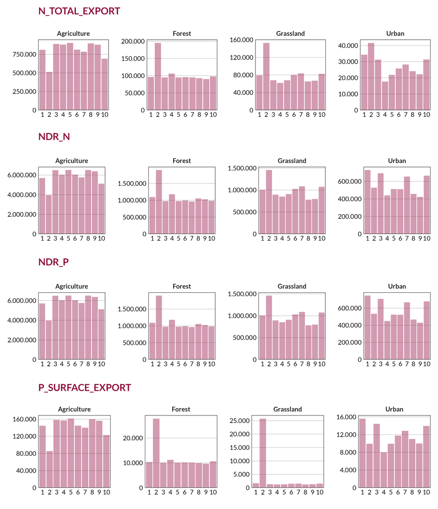

Figura 5.1: Figura de barras de nutrientes por clase y escenario

La siguiente tabla resume las cantidades y tipos de nutrientes, por clase y escenario disponible. Se agregó a la derecha una columna con la suma total de nutrientes por escenario.

**Ver código**

```r
nutri_files <- list.files(
  path = "datos/",
  pattern = "nutriente",
  full.names = TRUE
)[2:5]
nutri_tbl <- read_csv(nutri_files, show_col_types = FALSE)

nutri_tbl |>
  mutate(tipo = fct_reorder(tipo, sum)) |>
  arrange(tipo) |>
  pivot_wider(
    names_from = tipo,
    values_from = sum,
    id_cols = c(prod, esc)
  ) |>
  mutate(esc = paste0("Esc. ", esc)) |>
  mutate(prod = toupper(prod)) |>
  mutate(
    prod = factor(
      prod,
      levels = c("N_TOTAL_EXPORT", "NDR_N", "P_SURFACE_EXPORT", "NDR_P")
    )
  ) |>
  arrange(prod) |>
  rowwise() |>
  mutate(
    total = sum(c(Urban, Grassland, Forest, Agriculture))
  ) |>
  ungroup() |>
  gt(groupname_col = "prod", rowname_col = "esc") |>
  tab_stub_indent(indent = 5, rows = everything()) |>
  fmt_number(decimals = 0, dec_mark = ",", sep_mark = ".") |>
  tab_style(
    locations = cells_body(),
    style = cell_text(font = "JetBrains Mono")
  ) |>
  tab_style(
    locations = cells_row_groups(),
    style = cell_text(weight = "bold", color = "black")
  ) |>
  tab_style(
    locations = cells_body(columns = "total"),
    style = cell_fill(color = "grey93")
  ) |>
  tab_style(
    locations = cells_column_labels(columns = "total"),
    style = cell_fill(color = "grey93")
  ) |>
  tab_style(
    locations = cells_row_groups(groups = c("N_TOTAL_EXPORT", "NDR_N")),
    style = cell_fill(color = "#FFF8FB")
  ) |>
  tab_style(
    locations = cells_row_groups(groups = c("P_SURFACE_EXPORT", "NDR_P")),
    style = cell_fill(color = "#F1F9E5")
  ) |>
  tab_style(
    locations = cells_stub(),
    style = cell_fill(color = "grey97")
  ) |>
  tab_spanner(
    label = "Clase",
    columns = c("Urban", "Grassland", "Forest", "Agriculture")
  ) |>
  cols_label(
    esc = "Escenario",
    total = html("<i>Total por<br>escenario</i>")
  ) |>
  tab_source_note(
    source_note = md(
      glue(
        "Datos (.csv) disponibles para su [descarga {bsicons::bs_icon('download')} ](https://raw.githubusercontent.com/vhgauto/paisaje/refs/heads/main/datos/nutrientes_X_clase_X_escenario.csv)"
      )
    )
  ) |>
  tab_options(
    table.width = 700,
    table.border.top.style = "hidden",
    table.background.color = "transparent"
  ) |>
  as_raw_html()
```

Tabla 5.1: Tabla con los valores de nutrientes por clase, por escenario.

[output not shown]

Datos (.csv) disponibles para su [descarga](https://raw.githubusercontent.com/vhgauto/paisaje/refs/heads/main/datos/nutrientes_X_clase_X_escenario.csv)

## 5.2 Relación respecto del área

Tomando las cantidades de nutrientes asignados a cada clase, se calculó la proporción respecto del total de nutrientes por escenario. Luego, se comparó con el porcentaje de superficie cubierta por la clase correspondiente.

Dado que cada escenario generado conservó la misma proporción de áreas por clase, se calculó para un único vector, almacenando los resultados.

**Ver código**

```r
area_clase <- sf::st_area(sf_clases[[1]]) |>
  as.numeric()

area_clase_tbl <- tibble(
  area = area_clase,
  value = -1:2
) |>
  full_join(d_r, by = join_by(value)) |>
  mutate(area_prop = area / sum(area))

write_csv(area_clase_tbl, "datos/area_por_clase.csv")
```

Por cada escenario y clase, se compararon las proporciones respecto del área de la clase.

**Ver código**

```r
area_clase_csv <- list.files(
  path = "datos/",
  pattern = "area-clase-",
  full.names = TRUE
)

nutri_files <- list.files(
  path = "datos/",
  pattern = "nutriente",
  full.names = TRUE
)[2:5]
nutri_tbl <- read_csv(nutri_files, show_col_types = FALSE)

f_gg_area <- function(i_nutriente) {
  nutri_tbl |>
    mutate(tipo = fct_reorder(tipo, sum)) |>
    mutate(
      porcentaje = sum / sum(sum),
      .by = c(esc, prod)
    ) |>
    arrange(tipo) |>
    mutate(esc = factor(esc)) |>
    mutate(fraccion = sum / sum(sum), .by = c(esc, prod)) |>
    filter(prod == i_nutriente) |>
    ggplot(aes(esc, fraccion)) +
    geom_hline(
      data = area_clase_tbl,
      aes(yintercept = area_prop),
      alpha = .8,
      color = "#8E063B",
      linetype = 2,
      linewidth = 1
    ) +
    geom_line(aes(group = tipo), color = "#8E063B") +
    geom_point(color = "#8E063B") +
    facet_wrap(vars(tipo), nrow = 1, scales = "free") +
    scale_y_continuous(
      labels = scales::label_percent(
        accuracy = .1,
        big.mark = ".",
        decimal.mark = ","
      )
    ) +
    labs(x = NULL, y = NULL, title = toupper(i_nutriente)) +
    theme_bw(base_family = "Lato", base_size = 13) +
    theme(
      aspect.ratio = 1,
      plot.background = element_blank(),
      strip.placement = "outside",
      strip.text = element_text(face = "bold"),
      panel.background = element_blank(),
      panel.grid.minor = element_blank(),
      panel.grid.major = element_line(color = "grey30", linewidth = .1),
      axis.ticks = element_blank(),
      axis.text = element_text(color = "black"),
      axis.text.x = element_text(margin = margin(t = 0)),
      axis.text.y = element_text(margin = margin(r = 0)),
      panel.spacing.x = unit(.7, "cm")
    )
}

l_gg_area <- purrr::map(
  c("n_total_export", "ndr_n", "ndr_p", "p_surface_export"),
  f_gg_area
)

g4 <- wrap_plots(l_gg_area, ncol = 1) &
  theme(
    plot.title = element_text(face = "bold", color = "#8E063B"),
    plot.title.position = "panel",
    strip.background = element_blank(),
    plot.background = element_blank(),
    panel.background = element_blank()
  )

ggsave(
  plot = g4,
  filename = "figuras/nutrientes_porcentaje_clase.png",
  width = 25,
  height = 29,
  units = "cm"
)
```

**NotaMostrar figura**

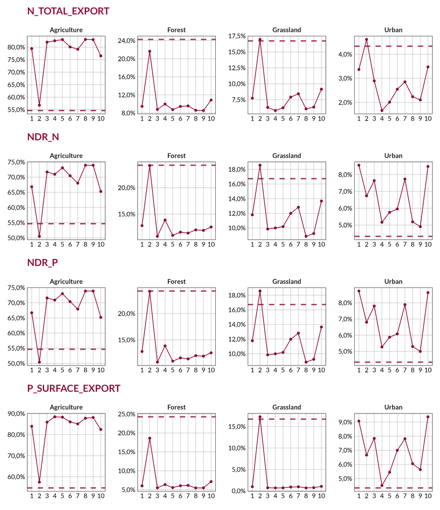

Figura 5.2: Porcentaje de nutrientes de cada clase, por escenario. En cada panel, la línea de trazos horizontal indica el porcentaje de superficie asociado a cada clase.

Tabla con las proporciones de nutrientes, por clase y escenario. A la derecha se muestran las proporciones de superficie de cada clase.

**Ver código**

```r
area_ref_tbl <- area_clase_tbl |>
  select(tipo, ref = area_prop)

area_gt_tbl <- nutri_tbl |>
  mutate(tipo = fct_reorder(tipo, sum)) |>
  mutate(
    fraccion = sum / sum(sum),
    .by = c(esc, prod)
  ) |>
  arrange(tipo) |>
  mutate(esc = paste0("Esc. ", esc)) |>
  mutate(esc = factor(esc)) |>
  pivot_wider(
    names_from = esc,
    values_from = fraccion,
    id_cols = c(prod, tipo)
  ) |>
  mutate(prod = toupper(prod)) |>
  mutate(
    prod = factor(
      prod,
      levels = c("N_TOTAL_EXPORT", "NDR_N", "P_SURFACE_EXPORT", "NDR_P")
    )
  ) |>
  arrange(prod) |>
  full_join(area_ref_tbl, by = join_by(tipo))

gt(area_gt_tbl, groupname_col = "prod", rowname_col = "tipo") |>
  tab_stub_indent(indent = 3, rows = everything()) |>
  fmt_percent(
    decimals = 1,
    sep_mark = ".",
    dec_mark = ","
  ) |>
  tab_style(
    locations = cells_body(),
    style = cell_text(font = "JetBrains Mono")
  ) |>
  tab_style(
    locations = cells_row_groups(),
    style = cell_text(weight = "bold", color = "black")
  ) |>
  tab_style(
    locations = cells_body(columns = "ref"),
    style = cell_fill(color = "grey93")
  ) |>
  tab_style(
    locations = cells_column_labels(columns = "ref"),
    style = cell_fill(color = "grey93")
  ) |>
  tab_style(
    locations = cells_row_groups(groups = c("N_TOTAL_EXPORT", "NDR_N")),
    style = cell_fill(color = "#FFF8FB")
  ) |>
  tab_style(
    locations = cells_row_groups(groups = c("P_SURFACE_EXPORT", "NDR_P")),
    style = cell_fill(color = "#F1F9E5")
  ) |>
  tab_style(
    locations = cells_stub(),
    style = cell_fill(color = "grey97")
  ) |>
  tab_spanner(
    label = "Escenario",
    columns = starts_with("esc")
  ) |>
  cols_width(ref ~ pct(8)) |>
  tab_style(
    style = cell_text(
      weight = "bold",
      decorate = "underline",
      color = "#8E063B"
    ),
    locations = purrr::map(
      1:nrow(area_gt_tbl),
      \(fila) {
        cells_body(
          columns = which(area_gt_tbl[fila, 3:12] > area_gt_tbl$ref[fila]) + 2,
          rows = fila
        )
      }
    )
  ) |>
  cols_label(
    ref = html("<i>% superficie<br>de la clase</i>")
  ) |>
  tab_footnote(
    footnote = html(
      "<b style='font-family: JetBrains Mono; color: #8E063B'>Texto
      destacado</b> indica que, en ese escenario, el nutriente asociado
      a la clase es <b><u>mayor</u></b> al porcentaje de superficie
      correspondiente."
    )
  ) |>
  tab_source_note(
    source_note = md(
      glue(
        "Datos (.csv) disponibles para su [descarga {bsicons::bs_icon('download')} ](https://raw.githubusercontent.com/vhgauto/paisaje/refs/heads/main/datos/fraccion_nutrientes_X_clase_X_escenario.csv)"
      )
    )
  ) |>
  tab_options(
    table.width = 1300,
    table.border.top.style = "hidden",
    table.background.color = "transparent"
  ) |>
  as_raw_html()
```

Tabla 5.2: Porcentaje de nutriente asignado a cada clase, por escenario.

[output not shown]

Datos (.csv) disponibles para su [descarga](https://raw.githubusercontent.com/vhgauto/paisaje/refs/heads/main/datos/fraccion_nutrientes_X_clase_X_escenario.csv)  
**Texto destacado** indica que, en ese escenario, el nutriente asociado a la clase es **mayor** al porcentaje de superficie correspondiente.

# 6 Cálculo de métricas de conectividad

**Ver código**

```r
max_distancias <- c(0, 10^(1:5))

m <- c("NC", "LNK", "SLC", "MSC", "CCP", "LCP", "CPL", "ECS", "AWF", "IIC")

m_nombres <- c(
  "Number of components",
  "Number of links",
  "Size of the Largest Component",
  "Mean Size of Components",
  "Class coincidence probability",
  "Landscape coincidence probability",
  "Characteristic path length",
  "Expected cluster size",
  "Area-weighted flux",
  "Integral index of connectivity"
)

m_nombres <- set_names(m_nombres, m)
```

El paquete utilizado fue [{lconnect}](https://github.com/FMestre1/lconnect) para el cálculo de las métricas de conectividad.

Los vectores procesados corresponden con las versiones vectorizadas de los escenarios sintéticos por cada dependencia del terreno.

Es requisito indicar un valor de distancia máxima. Se propusieron los siguientes valores: **0**, **10**, **100**, **1.000**, **10.000** y **100.000**.

## 6.1 Métricas de conectividad para LULC

Se calcularon las [métricas](https://github.com/FMestre1/lconnect?tab=readme-ov-file#these-are-the-landscape-connectivity-metrics-currently-provided) de conectividad para el vector original de clases.

**Ver código**

```r
v_lulc <- vect("vectores/lulc.gpkg")

v_lconnect_lulc <- purrr::map(
  max_distancias,
  purrr::in_parallel(
    \(x) {
      print(x)
      lconnect::upload_land(
        land_path = "vectores/lulc.gpkg",
        habitat = d$tipo,
        max_dist = x
      )
    }
  )
)

saveRDS(v_lconnect_lulc, "vectores/v_lconnect_lulc.rds")
```

La siguiente figura muestra las métricas.

**Ver código**

```r
v_lconnect_lulc <- readRDS("vectores/v_lconnect_lulc.rds")

m_conect_lulc <- purrr::map(
  v_lconnect_lulc,
  \(x, y) {
    metricas <- lconnect::con_metric(x, m)
    tibble(
      metric = metricas,
      tipo = names(metricas)
    ) |>
      mutate(max_d = x$max_dist)
  }
) |>
  purrr::list_rbind() |>
  mutate(max_d = factor(max_d)) |>
  mutate(tipo = factor(tipo, levels = m))

write_csv(m_conect_lulc, "datos/m_conect_lulc.csv")

g5 <- m_conect_lulc |>
  mutate(tipo = m_nombres[tipo]) |>
  mutate(tipo = factor(tipo, m_nombres)) |>
  drop_na() |>
  mutate(max_d = factor(max_d)) |>
  ggplot(aes(max_d, metric_lulc, group = tipo)) +
  geom_col(fill = alpha("#8E063B", .4), color = NA) +
  facet_wrap(
    vars(tipo),
    scales = "free_y",
    axis.labels = "all_x",
    nrow = 5
  ) +
  scale_x_discrete(
    breaks = factor(max_distancias),
    labels = c(0, 10, 100, "1E3", "1E4", "1E5")
  ) +
  labs(x = NULL, y = NULL) +
  theme_bw(base_size = 13, base_family = "JetBrains Mono") +
  theme(
    aspect.ratio = .5,
    plot.background = element_blank(),
    panel.spacing = unit(.6, "cm"),
    panel.background = element_blank(),
    panel.grid.major.y = element_line(color = "grey90"),
    panel.grid = element_blank(),
    strip.text = element_text(
      angle = 0,
      size = rel(1.1),
      hjust = .5,
      face = "bold",
      family = "Lato"
    ),
    strip.background = element_blank(),
    axis.text = element_text(size = rel(1), color = "black"),
    axis.ticks = element_blank()
  )

ggsave(
  plot = g5,
  filename = "figuras/lconnect_lulc.png",
  width = 25,
  height = 33,
  units = "cm"
)
```

**NotaMostrar figura**

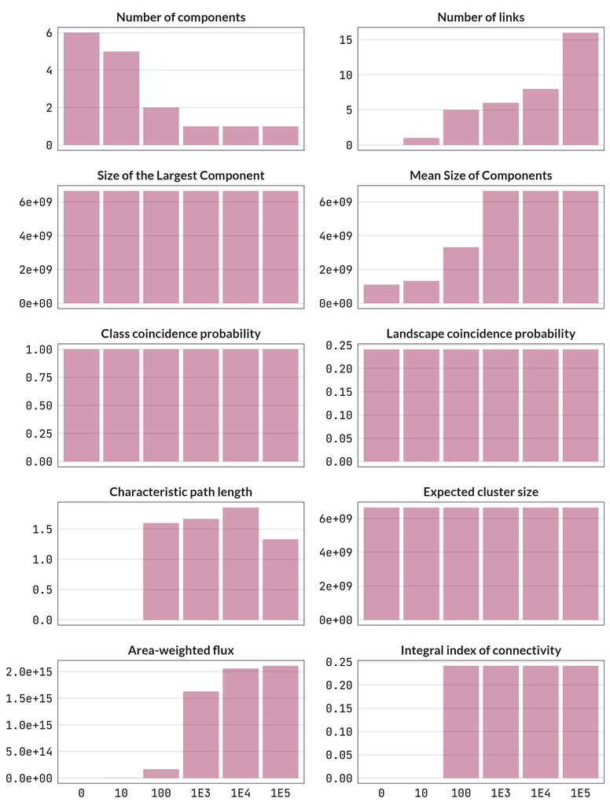

Figura 6.1: El eje horizontal indica la distancia máxima. En el eje vertival se lee el valor del íncide de cada panel.

## 6.2 Métricas de conectividad por escenarios

A partir de los diez escenarios propuestos, se calcularon las métricas de conectividad.

**Ver código**

```r
v_archivos <- list.files(
  path = "vectores/",
  pattern = "land-",
  full.names = TRUE
)

max_distancias <- c(0, 10^(1:5))

grilla <- expand_grid(
  archivos = v_archivos,
  max_d = max_distancias
)

{
  ti <- Sys.time()
  v_lconnect <- purrr::pmap(
    list(grilla$archivos, grilla$max_d),
    purrr::in_parallel(
      \(x, y) {
        print(paste0(x, " -- ", as.character(y)))
        lconnect::upload_land(
          x,
          habitat = -1:2,
          max_dist = y
        )
      }
    )
  )
  tf <- Sys.time()
  delta <- tf - ti # 5H 26M
}

saveRDS(v_lconnect, "vectores/v_lconnect.rds")
v_lconnect <- readRDS("vectores/v_lconnect.rds")

m_conect <- purrr::map2(
  v_lconnect,
  rep(1:10, each = 6),
  \(x, y) {
    metricas <- lconnect::con_metric(x, m)
    tibble(
      metric = metricas,
      tipo = names(metricas)
    ) |>
      mutate(max_d = x$max_dist) |>
      mutate(esc = y)
  }
) |>
  purrr::list_rbind() |>
  mutate(max_d = factor(max_d)) |>
  mutate(tipo = factor(tipo, levels = m))

write_csv(m_conect, "datos/m_conect.csv")
```

# 7 Cambio de conectividad

```r
connectivity = 4
terrain_dependency = 0.5
```

Se creó el escenario.

**Ver código**

```r
clases <- c(30, 40, 50) # Grassland, Agriculture, Urban

estructura_4 <- flsgen_extract_structure_from_raster(
  raster_file = r,
  focal_classes = clases,
  connectivity = 4
)

r_con4 <- flsgen_generate(
  estructura_4,
  terrain_file = dem,
  terrain_dependency = .5,
  connectivity = 4,
  epsg = "EPSG:22174",
  resolution_x = res(r)[1],
  resolution_y = res(r)[2],
  x = ext(dem)$"xmin",
  y = ext(dem)$"ymax"
)

writeRaster(r_con4, "rasters/r_con4.tif", overwrite = TRUE)
```

**Ver código**

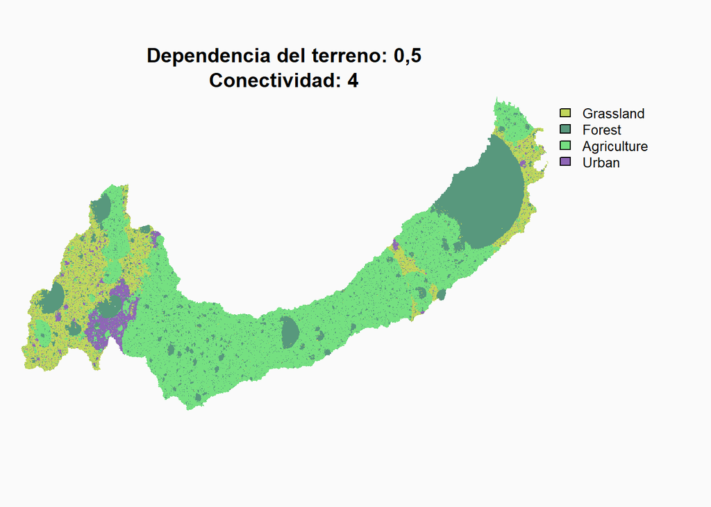

Figura 7.1: Mapa de clases considerando una conectividad 4.

```r
r_con4 <- rast("rasters/r_con4.tif")

# incorporo categorías y colores
levels(r_con4) <- d_r
coltab(r_con4) <- col_r_df

par(bg = "#FAFAFA")
plot(
  r_con4,
  axes = FALSE,
  mar = c(1, 1, 1, 8),
  main = "Dependencia del terreno: 0,5\nConectividad: 4",
  background = "#FAFAFA"
)
```

**Ver código**

```r
# métricas de clase
f_loop_clase_con4 <- function() {
  map2(
    .x = r_con4,
    .y = funciones_clase,
    ~ funcion_generica_clase(raster = .x, funcion = .y),
    .progress = TRUE
  ) |>
    list_rbind()
}

metrica_clase_con4 <- f_loop_clase_con4()
metrica_clase_con4 |>
  full_join(rename(d_r, class = value), by = join_by(class)) |>
  select(class, tipo, metric, value) |>
  write_csv("datos/con4_cla.csv")

# métricas de paisaje
f_loop_paisaje_con4 <- function() {
  map2(
    .x = r_con4,
    .y = funciones_paisaje,
    ~ funcion_generica_paisaje(raster = .x, funcion = .y),
    .progress = TRUE
  ) |>
    list_rbind()
}

metrica_paisaje_con4 <- f_loop_paisaje_con4()
metrica_paisaje_con4 |>
  select(metric, value) |>
  write_csv("datos/con4_pai.csv")

# métricas de conectividad
v_con4 <- as.polygons(r_con4) |>
  project("EPSG:32720")
writeVector(v_con4, "vectores/v_con4.gpkg")

max_distancias <- c(0, 10^(1:5))

l_con4 <- purrr::map(
  max_distancias,
  purrr::in_parallel(
    \(x) {
      print(x)
      lconnect::upload_land(
        land_path = "vectores/v_con4.gpkg",
        habitat = arrange(d_r, value)$tipo,
        max_dist = x
      )
    }
  )
)

saveRDS(l_con4, "vectores/l_con4.rds")
l_con4 <- readRDS("vectores/l_con4.rds")

m_conect_con4 <- purrr::map(
  l_con4,
  \(x, y) {
    metricas <- lconnect::con_metric(x, m)
    tibble(
      metric = metricas,
      tipo = names(metricas)
    ) |>
      mutate(max_d = x$max_dist)
  }
) |>
  purrr::list_rbind() |>
  mutate(max_d = factor(max_d)) |>
  mutate(tipo = factor(tipo, levels = m))

write_csv(m_conect_con4, "datos/m_conect_con4.csv")
```

## 7.1 Métricas de clase

**Ver código**

```r
metrica_clase_con4 <- read_csv(
  "datos/con4_cla.csv",
  show_col_types = FALSE
) |>
  select(-class) |>
  mutate(conectividad = 4)

clase_4_8 <- read_csv("datos/métricas_X_cla.csv", show_col_types = FALSE) |>
  filter(dependencia_terreno == .5) |>
  select(-dependencia_terreno) |>
  mutate(conectividad = 8) |>
  bind_rows(metrica_clase_con4) |>
  mutate(conectividad = paste0("Conec. ", conectividad)) |>
  pivot_wider(
    names_from = c(tipo, conectividad),
    values_from = value
  ) |>
  mutate(
    txt = map(metric, f_contenido_funcion)
  ) |>
  mutate(
    titulo = map_chr(txt, ~ .x[16])
  ) |>
  mutate(titulo = map_chr(titulo, f_titulo_funcion)) |>
  mutate(
    link = paste0(
      "https://r-spatialecology.github.io/landscapemetrics/reference/lsm_c_",
      metric,
      ".html"
    )
  ) |>
  mutate(
    metric = glue::glue("[{titulo}]({link})")
  ) |>
  select(-c(txt, titulo, link)) |>
  arrange(metric) |>
  relocate(1, 2, 6, 3, 7, 4, 8, 5, 9)

write_csv(clase_4_8, "datos/clase_4_8.csv")
```

La tabla muestra los valores de métricas de clase, para cada clase de suelo, considerando una dependencia del terreno 0,5, entre conectividad 4 y 8.

**Ver código**

```r
clase_4_8 <- read_csv("datos/clase_4_8.csv", show_col_types = FALSE)

clase_4_8 |>
  gt() |>
  fmt_auto(locale = "es", columns = -metric) |>
  fmt_url(columns = metric, color = "#8E063B") |>
  tab_style(
    locations = cells_body(columns = "metric"),
    style = cell_text(align = "left")
  ) |>
  tab_style(
    style = cell_text(
      weight = "bold",
      decorate = "underline",
      color = "#8E063B"
    ),
    locations = purrr::map(
      1:nrow(clase_4_8),
      \(fila) {
        cells_body(
          columns = c(
            which(clase_4_8[fila, 2] > clase_4_8[fila, 3]) + 1,
            which(clase_4_8[fila, 4] > clase_4_8[fila, 5]) + 3,
            which(clase_4_8[fila, 6] > clase_4_8[fila, 7]) + 5,
            which(clase_4_8[fila, 8] > clase_4_8[fila, 9]) + 7,
          ),
          rows = fila
        )
      }
    )
  ) |>
  tab_style(
    locations = cells_body(columns = -metric),
    style = cell_text(font = "JetBrains Mono")
  ) |>
  tab_spanner(
    columns = starts_with("Grassland"),
    label = "Grassland"
  ) |>
  tab_spanner(
    columns = starts_with("Forest"),
    label = "Forest"
  ) |>
  tab_spanner(
    columns = starts_with("Agriculture"),
    label = "Agriculture"
  ) |>
  tab_spanner(
    columns = starts_with("Urban"),
    label = "Urban"
  ) |>
  cols_label(
    ends_with("Conec. 8") ~ "Conec. 8",
    ends_with("Conec. 4") ~ "Conec. 4",
    metric ~ "Métrica"
  ) |>
  tab_footnote(
    footnote = html(
      "<b style='font-family: JetBrains Mono; color: #8E063B'>Texto
      destacado</b> indica que, para la clase correspondiente, la
      conectividad 8 posee una métrica <b><u>mayor</u></b> a la conectividad 4."
    )
  ) |>
  tab_source_note(
    source_note = md(
      glue::glue(
        "Datos (.csv) disponibles para su [descarga {bsicons::bs_icon('download')} ](https://raw.githubusercontent.com/vhgauto/paisaje/refs/heads/main/datos/clase_4_8.csv)"
      )
    )
  ) |>
  tab_options(
    table.border.top.style = "hidden",
    table.background.color = "transparent"
  )
```

Tabla 7.1: Tabla comparativa de métricas de clase.

| Métrica | Grassland Conec. 8 | Grassland Conec. 4 | Forest Conec. 8 | Forest Conec. 4 | Agriculture Conec. 8 | Agriculture Conec. 4 | Urban Conec. 8 | Urban Conec. 4 |
| --- | --- | --- | --- | --- | --- | --- | --- | --- |
| [Aggregation index](https://r-spatialecology.github.io/landscapemetrics/reference/lsm_c_ai.html) | 93,823 | 94,658 | 94,512 | 95,392 | 97,819 | 98,121 | 90,127 | 91,163 |
| [Clumpiness index](https://r-spatialecology.github.io/landscapemetrics/reference/lsm_c_clumpy.html) | 0,926 | 0,936 | 0,928 | 0,939 | 0,952 | 0,959 | 0,897 | 0,908 |
| [Core area percentage of landscape](https://r-spatialecology.github.io/landscapemetrics/reference/lsm_c_cpland.html) | 14,516 | 14,503 | 21,36 | 21,551 | 51,824 | 51,824 | 3,434 | 3,401 |
| [Disjunct core area density](https://r-spatialecology.github.io/landscapemetrics/reference/lsm_c_dcad.html) | 1,694 | 1,111 | 8,352 | 8,888 | 3,008 | 2,848 | 2,244 | 2,729 |
| [Edge Density](https://r-spatialecology.github.io/landscapemetrics/reference/lsm_c_ed.html) | 40,929 | 35,379 | 53,236 | 44,789 | 47,343 | 40,653 | 17,177 | 15,352 |
| [Effective Mesh Size](https://r-spatialecology.github.io/landscapemetrics/reference/lsm_c_mesh.html) | 11.883,031 | 7.327,568 | 11.194,37 | 10.003,315 | 108.247,679 | 101.937,297 | 454,133 | 427,797 |
| [Interspersion and Juxtaposition index](https://r-spatialecology.github.io/landscapemetrics/reference/lsm_c_iji.html) | 98,267 | 98,874 | 73,01 | 73,445 | 68,396 | 69,785 | 74,244 | 74,38 |
| [Landscape division index](https://r-spatialecology.github.io/landscapemetrics/reference/lsm_c_division.html) | 0,982 | 0,989 | 0,983 | 0,985 | 0,837 | 0,847 | 0,999 | 0,999 |
| [Landscape shape index](https://r-spatialecology.github.io/landscapemetrics/reference/lsm_c_lsi.html) | 206,932 | 179,104 | 221,398 | 186,048 | 132,462 | 114,282 | 168,462 | 150,903 |
| [Largest patch index](https://r-spatialecology.github.io/landscapemetrics/reference/lsm_c_lpi.html) | 13,294 | 9,831 | 12,821 | 12,12 | 38,491 | 38,297 | 2,593 | 2,528 |
| [Mean fractal dimension index](https://r-spatialecology.github.io/landscapemetrics/reference/lsm_c_frac_mn.html) | 1,029 | 1,02 | 1,207 | 1,119 | 1,208 | 1,12 | 1,207 | 1,119 |
| [Mean number of disjunct core areas](https://r-spatialecology.github.io/landscapemetrics/reference/lsm_c_dcore_mn.html) | 0,1 | 0,083 | 1,211 | 0,827 | 1,625 | 0,943 | 0,975 | 0,759 |
| [Mean of Contiguity index](https://r-spatialecology.github.io/landscapemetrics/reference/lsm_c_contig_mn.html) | 0,07 | 0,074 | 0,442 | 0,528 | 0,431 | 0,52 | 0,425 | 0,514 |
| [Mean of core area index](https://r-spatialecology.github.io/landscapemetrics/reference/lsm_c_cai_mn.html) | 0,978 | 1,204 | 9,467 | 13,795 | 8,321 | 12,626 | 7,383 | 11,555 |
| [Mean of core area](https://r-spatialecology.github.io/landscapemetrics/reference/lsm_c_core_mn.html) | 0,861 | 1,078 | 3,096 | 2,005 | 27,997 | 17,163 | 1,492 | 0,946 |
| [Mean of patch area](https://r-spatialecology.github.io/landscapemetrics/reference/lsm_c_area_mn.html) | 0,992 | 1,243 | 3,518 | 2,258 | 29,537 | 18,107 | 1,882 | 1,206 |
| [Mean of related circumscribing circle](https://r-spatialecology.github.io/landscapemetrics/reference/lsm_c_circle_mn.html) | 0,436 | 0,42 | 0,679 | 0,593 | 0,685 | 0,599 | 0,688 | 0,603 |
| [Mean perimeter-area ratio](https://r-spatialecology.github.io/landscapemetrics/reference/lsm_c_para_mn.html) | 0,37 | 0,366 | 0,221 | 0,17 | 0,225 | 0,173 | 0,228 | 0,175 |
| [Mean radius of gyration](https://r-spatialecology.github.io/landscapemetrics/reference/lsm_c_gyrate_mn.html) | 3,432 | 3,271 | 28,757 | 22,516 | 31,643 | 24,544 | 25,638 | 20,271 |
| [Mean shape index](https://r-spatialecology.github.io/landscapemetrics/reference/lsm_c_shape_mn.html) | 1,118 | 1,078 | 2,347 | 1,612 | 2,351 | 1,623 | 2,302 | 1,596 |
| [Normalized landscape shape index](https://r-spatialecology.github.io/landscapemetrics/reference/lsm_c_nlsi.html) | 0,062 | 0,053 | 0,055 | 0,046 | 0,026 | 0,022 | 0,099 | 0,088 |
| [Number of disjunct core areas](https://r-spatialecology.github.io/landscapemetrics/reference/lsm_c_ndca.html) | 11.262 | 7.386 | 55.537 | 59.098 | 20.004 | 18.936 | 14.922 | 18.144 |
| [Number of patches](https://r-spatialecology.github.io/landscapemetrics/reference/lsm_c_np.html) | 112.065 | 89.471 | 45.871 | 71.469 | 12.308 | 20.078 | 15.311 | 23.893 |
| [Patch Cohesion Index](https://r-spatialecology.github.io/landscapemetrics/reference/lsm_c_cohesion.html) | 99,958 | 99,945 | 99,104 | 98,851 | 99,98 | 99,977 | 99,668 | 99,641 |
| [Patch density](https://r-spatialecology.github.io/landscapemetrics/reference/lsm_c_pd.html) | 16,854 | 13,456 | 6,899 | 10,748 | 1,851 | 3,02 | 2,303 | 3,593 |
| [Percentage of Like Adjacencies](https://r-spatialecology.github.io/landscapemetrics/reference/lsm_c_pladj.html) | 93,795 | 94,629 | 94,488 | 95,368 | 97,803 | 98,105 | 90,074 | 91,109 |
| [Percentage of landscape of class](https://r-spatialecology.github.io/landscapemetrics/reference/lsm_c_pland.html) | 16,726 | 16,726 | 24,266 | 24,266 | 54,675 | 54,675 | 4,333 | 4,333 |
| [Perimeter-Area Fractal Dimension](https://r-spatialecology.github.io/landscapemetrics/reference/lsm_c_pafrac.html) | 1,45 | 1,328 | 1,501 | 1,372 | 1,53 | 1,399 | 1,568 | 1,422 |
| [Splitting index](https://r-spatialecology.github.io/landscapemetrics/reference/lsm_c_split.html) | 55,956 | 90,743 | 59,398 | 66,471 | 6,143 | 6,523 | 1.464,166 | 1.554,302 |
| [Total (class) area](https://r-spatialecology.github.io/landscapemetrics/reference/lsm_c_ca.html) | 111.216,18 | 111.216,18 | 161.353,18 | 161.353,18 | 363.546,06 | 363.546,06 | 28.810,5 | 28.810,5 |
| [Total (class) edge](https://r-spatialecology.github.io/landscapemetrics/reference/lsm_c_te.html) | 2,722 × 10<sup>7</sup> | 2,352 × 10<sup>7</sup> | 3,540 × 10<sup>7</sup> | 2,978 × 10<sup>7</sup> | 3,148 × 10<sup>7</sup> | 2,703 × 10<sup>7</sup> | 1,142 × 10<sup>7</sup> | 1,021 × 10<sup>7</sup> |
| [Total core area](https://r-spatialecology.github.io/landscapemetrics/reference/lsm_c_tca.html) | 96.523,75 | 96.435,38 | 142.030,35 | 143.300,44 | 344.591,77 | 344.593,06 | 22.836,59 | 22.611,12 |

Datos (.csv) disponibles para su [descarga](https://raw.githubusercontent.com/vhgauto/paisaje/refs/heads/main/datos/clase_4_8.csv)  
**Texto destacado** indica que, para la clase correspondiente, la conectividad 8 posee una métrica **mayor** a la conectividad 4.

## 7.2 Métricas de paisaje

**Ver código**

```r
metrica_paisaje_con4 <- read_csv(
  "datos/con4_pai.csv",
  show_col_types = FALSE
) |>
  mutate(conectividad = 4)

paisaje_4_8 <- read_csv("datos/métricas_X_pai.csv", show_col_types = FALSE) |>
  filter(dependencia_terreno == .5) |>
  select(-dependencia_terreno) |>
  mutate(conectividad = 8) |>
  bind_rows(metrica_paisaje_con4) |>
  mutate(conectividad = paste0("Conec. ", conectividad)) |>
  pivot_wider(
    names_from = conectividad,
    values_from = value
  ) |>
  mutate(
    txt = map(metric, f_contenido_funcion2)
  ) |>
  mutate(
    titulo = map_chr(txt, ~ .x[16])
  ) |>
  mutate(titulo = map_chr(titulo, f_titulo_funcion)) |>
  mutate(
    link = paste0(
      "https://r-spatialecology.github.io/landscapemetrics/reference/lsm_l_",
      metric,
      ".html"
    )
  ) |>
  mutate(
    metric = glue::glue("[{titulo}]({link})")
  ) |>
  select(1:3) |>
  arrange(metric)

write_csv(paisaje_4_8, "datos/paisaje_4_8.csv")
```

La tabla muestra los valores de métricas de paisaje, para cada clase de suelo, considerando una dependencia del terreno 0,5, entre conectividad 4 y 8.

**Ver código**

```r
paisaje_4_8 <- read_csv("datos/paisaje_4_8.csv", show_col_types = FALSE)

paisaje_4_8 |>
  gt() |>
  fmt_auto(locale = "es", columns = -metric) |>
  fmt_url(columns = metric, color = "#8E063B") |>
  tab_style(
    locations = cells_body(columns = "metric"),
    style = cell_text(align = "left")
  ) |>
  tab_style(
    style = cell_text(
      weight = "bold",
      decorate = "underline",
      color = "#8E063B"
    ),
    locations = purrr::map(
      1:nrow(paisaje_4_8),
      \(fila) {
        cells_body(
          columns = c(
            which(paisaje_4_8[fila, 2] > paisaje_4_8[fila, 3]) + 1
          ),
          rows = fila
        )
      }
    )
  ) |>
  tab_style(
    locations = cells_body(columns = -metric),
    style = cell_text(font = "JetBrains Mono")
  ) |>
  cols_label(
    metric ~ "Métrica"
  ) |>
  tab_footnote(
    footnote = html(
      "<b style='font-family: JetBrains Mono; color: #8E063B'>Texto
      destacado</b> indica que, para la métrica correspondiente, la
      conectividad 8 es <b><u>mayor</u></b> a la conectividad 4."
    )
  ) |>
  tab_source_note(
    source_note = md(
      glue::glue(
        "Datos (.csv) disponibles para su [descarga {bsicons::bs_icon('download')} ](https://raw.githubusercontent.com/vhgauto/paisaje/refs/heads/main/datos/paisaje_4_8.csv)"
      )
    )
  ) |>
  sub_missing() |>
  tab_options(
    table.border.top.style = "hidden",
    table.background.color = "transparent"
  ) |>
  as_raw_html()
```

Tabla 7.2: Tabla comparativa de métricas de paisaje.

| Métrica | Conec. 8 | Conec. 4 |
| --- | --- | --- |
| [Aggregation index](https://r-spatialecology.github.io/landscapemetrics/reference/lsm_l_ai.html) | 96,015 | 96,578 |
| [Conditional entropy \[H(y\|x)\]](https://r-spatialecology.github.io/landscapemetrics/reference/lsm_l_condent.html) | 0,282 | 0,25 |
| [Contagion](https://r-spatialecology.github.io/landscapemetrics/reference/lsm_l_contag.html) | 52,964 | 53,763 |
| [Disjunct core area density](https://r-spatialecology.github.io/landscapemetrics/reference/lsm_l_dcad.html) | 15,299 | 15,575 |
| [Edge Density](https://r-spatialecology.github.io/landscapemetrics/reference/lsm_l_ed.html) | 79,343 | 68,087 |
| [Effective Mesh Size](https://r-spatialecology.github.io/landscapemetrics/reference/lsm_l_mesh.html) | 131.779,212 | 119.695,976 |
| [Interspersion and Juxtaposition index](https://r-spatialecology.github.io/landscapemetrics/reference/lsm_l_iji.html) | 82,84 | 83,624 |
| [Joint entropy \[H(x, y)\]](https://r-spatialecology.github.io/landscapemetrics/reference/lsm_l_joinent.html) | 1,881 | 1,849 |
| [Landscape division index](https://r-spatialecology.github.io/landscapemetrics/reference/lsm_l_division.html) | 0,802 | 0,82 |
| [Landscape shape index](https://r-spatialecology.github.io/landscapemetrics/reference/lsm_l_lsi.html) | 164,963 | 142,016 |
| [Largest patch index](https://r-spatialecology.github.io/landscapemetrics/reference/lsm_l_lpi.html) | 38,491 | 38,297 |
| [Marginal entropy \[H(x)\]](https://r-spatialecology.github.io/landscapemetrics/reference/lsm_l_ent.html) | 1,6 | 1,6 |
| [Mean fractal dimension index](https://r-spatialecology.github.io/landscapemetrics/reference/lsm_l_frac_mn.html) | 1,1 | 1,076 |
| [Mean number of disjunct core areas](https://r-spatialecology.github.io/landscapemetrics/reference/lsm_l_dcore_mn.html) | 0,548 | 0,505 |
| [Mean of Contiguity index](https://r-spatialecology.github.io/landscapemetrics/reference/lsm_l_contig_mn.html) | 0,215 | 0,327 |
| [Mean of core area index](https://r-spatialecology.github.io/landscapemetrics/reference/lsm_l_cai_mn.html) | 4,092 | 7,922 |
| [Mean of core area](https://r-spatialecology.github.io/landscapemetrics/reference/lsm_l_core_mn.html) | 3,266 | 2,962 |
| [Mean of patch area](https://r-spatialecology.github.io/landscapemetrics/reference/lsm_l_area_mn.html) | 3,583 | 3,245 |
| [Mean of related circumscribing circle](https://r-spatialecology.github.io/landscapemetrics/reference/lsm_l_circle_mn.html) | 0,533 | 0,519 |
| [Mean perimeter-area ratio](https://r-spatialecology.github.io/landscapemetrics/reference/lsm_l_para_mn.html) | 0,312 | 0,257 |
| [Mean radius of gyration](https://r-spatialecology.github.io/landscapemetrics/reference/lsm_l_gyrate_mn.html) | 13,396 | 14,05 |
| [Mean shape index](https://r-spatialecology.github.io/landscapemetrics/reference/lsm_l_shape_mn.html) | 1,601 | 1,378 |
| [Modified Simpson's diversity index](https://r-spatialecology.github.io/landscapemetrics/reference/lsm_l_msidi.html) | 0,948 | 0,948 |
| [Modified Simpson's evenness index](https://r-spatialecology.github.io/landscapemetrics/reference/lsm_l_msiei.html) | 0,684 | 0,684 |
| [Mutual information \[I(y,x)\]](https://r-spatialecology.github.io/landscapemetrics/reference/lsm_l_mutinf.html) | 1,318 | 1,35 |
| [Number of disjunct core areas](https://r-spatialecology.github.io/landscapemetrics/reference/lsm_l_ndca.html) | 101.725 | 103.564 |
| [Number of patches](https://r-spatialecology.github.io/landscapemetrics/reference/lsm_l_np.html) | 185.555 | 204.911 |
| [Patch Cohesion Index](https://r-spatialecology.github.io/landscapemetrics/reference/lsm_l_cohesion.html) | 99,944 | 99,936 |
| [Patch density](https://r-spatialecology.github.io/landscapemetrics/reference/lsm_l_pd.html) | 27,906 | 30,817 |
| [Patch richness density](https://r-spatialecology.github.io/landscapemetrics/reference/lsm_l_prd.html) | 6,016 × 10<sup>−4</sup> | 6,016 × 10<sup>−4</sup> |
| [Patch richness](https://r-spatialecology.github.io/landscapemetrics/reference/lsm_l_pr.html) | 4 | 4 |
| [Percentage of Like Adjacencies](https://r-spatialecology.github.io/landscapemetrics/reference/lsm_l_pladj.html) | 96,031 | 96,594 |
| [Perimeter-Area Fractal Dimension](https://r-spatialecology.github.io/landscapemetrics/reference/lsm_l_pafrac.html) | 1,539 | 1,347 |
| [Relative mutual information](https://r-spatialecology.github.io/landscapemetrics/reference/lsm_l_relmutinf.html) | 0,824 | 0,844 |
| [Relative patch richness](https://r-spatialecology.github.io/landscapemetrics/reference/lsm_l_rpr.html) | — | — |
| [Shannon's diversity index](https://r-spatialecology.github.io/landscapemetrics/reference/lsm_l_shdi.html) | 1,109 | 1,109 |
| [Shannons's evenness index](https://r-spatialecology.github.io/landscapemetrics/reference/lsm_l_shei.html) | 0,8 | 0,8 |
| [Simpson's diversity index](https://r-spatialecology.github.io/landscapemetrics/reference/lsm_l_sidi.html) | 0,612 | 0,612 |
| [Simpson's evenness index](https://r-spatialecology.github.io/landscapemetrics/reference/lsm_l_siei.html) | 0,816 | 0,816 |
| [Splitting index](https://r-spatialecology.github.io/landscapemetrics/reference/lsm_l_split.html) | 5,046 | 5,555 |
| [Total area](https://r-spatialecology.github.io/landscapemetrics/reference/lsm_l_ta.html) | 664.925,92 | 664.925,92 |
| [Total core area](https://r-spatialecology.github.io/landscapemetrics/reference/lsm_l_tca.html) | 605.982,46 | 606.940 |
| [Total edge](https://r-spatialecology.github.io/landscapemetrics/reference/lsm_l_te.html) | 5,276 × 10<sup>7</sup> | 4,527 × 10<sup>7</sup> |

Datos (.csv) disponibles para su [descarga](https://raw.githubusercontent.com/vhgauto/paisaje/refs/heads/main/datos/paisaje_4_8.csv)  
**Texto destacado** indica que, para la métrica correspondiente, la conectividad 8 es **mayor** a la conectividad 4.

## 7.3 Métricas de conectividad

**Ver código**

```r
metrica_conectividad_con4 <- read_csv(
  "datos/m_conect_con4.csv",
  show_col_types = FALSE
) |>
  mutate(conectividad = 4)

conectividad_4_8 <- read_csv("datos/m_conect.csv", show_col_types = FALSE) |>
  filter(esc == 5) |>
  select(-esc) |>
  mutate(conectividad = 8) |>
  bind_rows(metrica_conectividad_con4) |>
  mutate(conectividad = paste0("Conec. ", conectividad)) |>
  pivot_wider(
    names_from = conectividad,
    values_from = metric
  ) |>
  mutate(tipo = m_nombres[tipo]) |>
  mutate(
    max_d = format(
      max_d,
      big.mark = ".",
      decimal.mark = ",",
      scientific = FALSE
    )
  ) |>
  mutate(max_d = paste0("Distancia Máx: ", max_d))

write_csv(conectividad_4_8, "datos/conectividad_4_8.csv")
```

La tabla muestra los valores de métricas de conectividad, considerando una dependencia del terreno 0,5, entre conectividad 4 y 8.

**Ver código**

```r
conectividad_4_8 <- read_csv(
  "datos/conectividad_4_8.csv",
  show_col_types = FALSE
)

conectividad_4_8 |>
  gt(rowname_col = "tipo", groupname_col = "max_d") |>
  fmt_auto(locale = "es") |>
  sub_missing() |>
  tab_style(
    locations = cells_row_groups(),
    style = list(
      cell_fill(color = alpha("#8E063B", .2)),
      cell_text(weight = "bold")
    )
  ) |>
  tab_style(
    locations = cells_body(),
    style = cell_text(font = "JetBrains Mono")
  ) |>
  tab_source_note(
    source_note = md(
      glue::glue(
        "Datos (.csv) disponibles para su [descarga {bsicons::bs_icon('download')} ](https://raw.githubusercontent.com/vhgauto/paisaje/refs/heads/main/datos/conectividad_4_8.csv)"
      )
    )
  ) |>
  tab_options(
    table.border.top.style = "hidden",
    table.background.color = "transparent"
  ) |>
  as_raw_html()
```

Tabla 7.3: Tabla comparativa de métricas de conectividad

|  | Conec. 8 | Conec. 4 |
| --- | --- | --- |
| Distancia Máx: 0 |  |  |
| Number of components | 6 | 6 |
| Number of links | 0 | 0 |
| Size of the Largest Component | 6,644 × 10<sup>9</sup> | 6,644 × 10<sup>9</sup> |
| Mean Size of Components | 1,107 × 10<sup>9</sup> | 1,107 × 10<sup>9</sup> |
| Class coincidence probability | 1 | 1 |
| Landscape coincidence probability | 0,241 | 0,241 |
| Characteristic path length | — | — |
| Expected cluster size | 6,644 × 10<sup>9</sup> | 6,644 × 10<sup>9</sup> |
| Area-weighted flux | — | — |
| Integral index of connectivity | 0 | 0 |
| Distancia Máx: 10 |  |  |
| Number of components | 5 | 5 |
| Number of links | 2 | 2 |
| Size of the Largest Component | 6,644 × 10<sup>9</sup> | 6,644 × 10<sup>9</sup> |
| Mean Size of Components | 1,329 × 10<sup>9</sup> | 1,329 × 10<sup>9</sup> |
| Class coincidence probability | 1 | 1 |
| Landscape coincidence probability | 0,241 | 0,241 |
| Characteristic path length | 1 | 1 |
| Expected cluster size | 6,644 × 10<sup>9</sup> | 6,644 × 10<sup>9</sup> |
| Area-weighted flux | 4,609 × 10<sup>12</sup> | 4,609 × 10<sup>12</sup> |
| Integral index of connectivity | 0,241 | 0,241 |
| Distancia Máx: 100 |  |  |
| Number of components | 2 | 2 |
| Number of links | 5 | 5 |
| Size of the Largest Component | 6,644 × 10<sup>9</sup> | 6,644 × 10<sup>9</sup> |
| Mean Size of Components | 3,322 × 10<sup>9</sup> | 3,322 × 10<sup>9</sup> |
| Class coincidence probability | 1 | 1 |
| Landscape coincidence probability | 0,241 | 0,241 |
| Characteristic path length | 1,6 | 1,6 |
| Expected cluster size | 6,644 × 10<sup>9</sup> | 6,644 × 10<sup>9</sup> |
| Area-weighted flux | 1,654 × 10<sup>14</sup> | 1,654 × 10<sup>14</sup> |
| Integral index of connectivity | 0,241 | 0,241 |
| Distancia Máx: 1.000 |  |  |
| Number of components | 1 | 1 |
| Number of links | 6 | 6 |
| Size of the Largest Component | 6,644 × 10<sup>9</sup> | 6,644 × 10<sup>9</sup> |
| Mean Size of Components | 6,644 × 10<sup>9</sup> | 6,644 × 10<sup>9</sup> |
| Class coincidence probability | 1 | 1 |
| Landscape coincidence probability | 0,241 | 0,241 |
| Characteristic path length | 1,667 | 1,667 |
| Expected cluster size | 6,644 × 10<sup>9</sup> | 6,644 × 10<sup>9</sup> |
| Area-weighted flux | 1,624 × 10<sup>15</sup> | 1,624 × 10<sup>15</sup> |
| Integral index of connectivity | 0,241 | 0,241 |
| Distancia Máx: 10.000 |  |  |
| Number of components | 1 | 1 |
| Number of links | 8 | 8 |
| Size of the Largest Component | 6,644 × 10<sup>9</sup> | 6,644 × 10<sup>9</sup> |
| Mean Size of Components | 6,644 × 10<sup>9</sup> | 6,644 × 10<sup>9</sup> |
| Class coincidence probability | 1 | 1 |
| Landscape coincidence probability | 0,241 | 0,241 |
| Characteristic path length | 1,857 | 1,857 |
| Expected cluster size | 6,644 × 10<sup>9</sup> | 6,644 × 10<sup>9</sup> |
| Area-weighted flux | 2,057 × 10<sup>15</sup> | 2,057 × 10<sup>15</sup> |
| Integral index of connectivity | 0,241 | 0,241 |
| Distancia Máx: 100.000 |  |  |
| Number of components | 1 | 1 |
| Number of links | 16 | 16 |
| Size of the Largest Component | 6,644 × 10<sup>9</sup> | 6,644 × 10<sup>9</sup> |
| Mean Size of Components | 6,644 × 10<sup>9</sup> | 6,644 × 10<sup>9</sup> |
| Class coincidence probability | 1 | 1 |
| Landscape coincidence probability | 0,241 | 0,241 |
| Characteristic path length | 1,333 | 1,333 |
| Expected cluster size | 6,644 × 10<sup>9</sup> | 6,644 × 10<sup>9</sup> |
| Area-weighted flux | 2,107 × 10<sup>15</sup> | 2,107 × 10<sup>15</sup> |
| Integral index of connectivity | 0,241 | 0,241 |

Datos (.csv) disponibles para su [descarga](https://raw.githubusercontent.com/vhgauto/paisaje/refs/heads/main/datos/conectividad_4_8.csv)